# Predators mitigate the destabilizing effects of heatwaves on multitrophic stream communities

Samuel R.P-J. Ross

15/06/2021

This Markdown is for reproducing the analysis from Ross *et al.* (Submitted, *Journal Name*). We have loaded all required data and will test whether heatwaves and predator presence/absence affect multiple aspects of multitrophic stream mesocosm communities. First we’ll look for treatment effects on algal biomass and functional stability (temporal and spatial variability), then on compositional structure and stability (temporal and spatial variability), and finally on macroinvertebrate community structure, richness, density, and leaf litter processing by microbes and macroinvertebrates.

We will do all of this over two time periods: one during/immediately following the application of our experimental heatwaves, and one during/at the end of a 20-day recovery period (see Methods in Ross *et al.*).

## Functional (biomass) stability

We’ll start by looking for treatment effects on algal biomass and functional temporal and spatial variability.

**Mean values**

First, we’ll use the mean of our tiles within each mesocosm to look for treatment effects on algal biomass and temporal variability. Then later we’ll compare the tiles within mesocosms as our measure of spatial variability.

```r
# Here we'll get the mean values to use for our plots. We can use $Mesocosm.No as an index to calculate across the three spatial replicates each day

Bentho.Mean<-distinct(Bentho,Date,Mesocosm.No,.keep_all = TRUE) # for each date get unique date x mesocosm.no
Bentho.Mean<-Bentho.Mean[,c(1,6:9,11)] # remove data
Bentho.Mean<-as.data.frame(Bentho.Mean) # convert to dataframe to allow cbind
Bentho.Mean<-cbind(Bentho.Mean,Total.Mean=NA) # cbind the mean column on

# get mean of each variable for each date x mesocosm
for (i in 1:nrow(Bentho.Mean)) {
  Bentho.Mean$Total.Mean[i]<-mean(Bentho[Bentho$Date %in% Bentho.Mean$Date[i] & Bentho$Mesocosm.No %in%
                                  Bentho.Mean$Mesocosm.No[i],]$Total.Conc) # get mean of total chlorophyll
}

Bentho.Mean$Mesocosm.No<-as.character(Bentho.Mean$Mesocosm.No)

# label appropriate periods
Bentho.Mean$Period2<-NA
Bentho.Mean$Period2[Bentho.Mean$Period %in% "Initial"]<-"Colonisation"
Bentho.Mean$Period2[Bentho.Mean$Period %in% "Recovery"]<-"Recovery"
Bentho.Mean$Period2[Bentho.Mean$Period %in% c("Ambient","Ambient.1","Ambient.2")]<-"Control"
Bentho.Mean$Period2[Bentho.Mean$Date %in% parse_datetime(c("2019-07-30","2019-07-31"),locale = locale(tz = "Japan")) &
                      Bentho.Mean$Heat.Treatment %!in% "Ambient"]<-"Onset"
Bentho.Mean$Period2[Bentho.Mean$Date %in% parse_datetime(c("2019-08-01","2019-08-02","2019-08-03","2019-08-04","2019-08-05"),
                                                         locale = locale(tz = "Japan")) &
                      Bentho.Mean$Heat.Treatment %!in% "Ambient"]<-"Peak"
Bentho.Mean$Period2[Bentho.Mean$Date %in% parse_datetime(c("2019-08-06","2019-08-07","2019-08-08"),
                                                         locale = locale(tz = "Japan")) &
                      Bentho.Mean$Heat.Treatment %!in% "Ambient"]<-"Decline"

Bentho.Mean$Period2<-parse_factor(Bentho.Mean$Period2,
                                   levels = c("Control","Colonisation","Onset","Peak","Decline","Recovery"),
                                   ordered = T,
                                   include_na = F)
```

We’ll separate out our time points on 2 specific dates: 1) the final day of peak heating, and 2) the final day of the experiment after 20-days of post-heatwave recovery.

```r
# 1) End of peak heatwave
Peak.end<-Bentho.Mean[Bentho.Mean$Date %in% parse_datetime("2019-08-05",locale = locale(tz = "Japan")),]

# 2) End of experiment
Recovery.end<-Bentho.Mean[Bentho.Mean$Date %in% parse_datetime("2019-08-28",locale = locale(tz = "Japan")),]
```

**Treatment effects on biomass**

Now we’ll do the stats to test for treatment effects on algal biomass:

```r
##-- End of Heatwave Peak --##
# hist(Peak.end$Total.Mean) # assess normality (not run)
summary(aov(Total.Mean~Pred.Treatment*Heat.Treatment,data = Peak.end)) # run anova
```

```
##                               Df Sum Sq Mean Sq F value Pr(>F)
## Pred.Treatment                 1  0.392  0.3924   0.968  0.331
## Heat.Treatment                 2  0.528  0.2638   0.651  0.527
## Pred.Treatment:Heat.Treatment  2  0.374  0.1869   0.461  0.634
## Residuals                     42 17.030  0.4055
```

```r
# plot(aov(Total.Mean~Pred.Treatment*Heat.Treatment,data = Peak.end)) # check assumption of homoscedasticity (not run)

##-- End of Recovery Period --##
# hist(Recovery.end$Total.Mean) # assess normality (not run)
summary(aov(Total.Mean~Pred.Treatment*Heat.Treatment,data = Recovery.end)) # run anova
```

```
##                               Df Sum Sq Mean Sq F value   Pr(>F)
## Pred.Treatment                 1  5.271   5.271  22.071 2.82e-05 ***
## Heat.Treatment                 2  6.303   3.151  13.194 3.58e-05 ***
## Pred.Treatment:Heat.Treatment  2  0.196   0.098   0.411    0.666
## Residuals                     42 10.031   0.239
## ---
## Signif. codes:  0 '***' 0.001 '**' 0.01 '*' 0.05 '.' 0.1 ' ' 1
```

```r
# plot(aov(Total.Mean~Pred.Treatment*Heat.Treatment,data = Recovery.end)) # check assumption of homoscedasticity (not run)
TukeyHSD(aov(Total.Mean~Pred.Treatment*Heat.Treatment,data = Recovery.end)) # Tukey's HSD post-hoc test checks significance of group differences (not run)
```

```
##   Tukey multiple comparisons of means
##     95% family-wise confidence level
##
## Fit: aov(formula = Total.Mean ~ Pred.Treatment * Heat.Treatment, data = Recovery.end)
##
## $Pred.Treatment
##                      diff        lwr        upr    p adj
## Absent-Present -0.6627778 -0.9474861 -0.3780695 2.82e-05
##
## $Heat.Treatment
##                       diff        lwr       upr     p adj
## Current-Ambient 0.08166667 -0.3381144 0.5014477 0.8844893
## Future-Ambient  0.80625000  0.3864689 1.2260311 0.0000912
## Future-Current  0.72458333  0.3048023 1.1443644 0.0004004
##
## $`Pred.Treatment:Heat.Treatment`
##                                        diff         lwr         upr     p adj
## Absent:Ambient-Present:Ambient  -0.63666667 -1.36612851  0.09279518 0.1183754
## Present:Current-Present:Ambient  0.17875000 -0.55071184  0.90821184 0.9768530
## Absent:Current-Present:Ambient  -0.65208333 -1.38154518  0.07737851 0.1033931
## Present:Future-Present:Ambient   0.74833333  0.01887149  1.47779518 0.0414220
## Absent:Future-Present:Ambient    0.22750000 -0.50196184  0.95696184 0.9361654
## Present:Current-Absent:Ambient   0.81541667  0.08595482  1.54487851 0.0205712
## Absent:Current-Absent:Ambient   -0.01541667 -0.74487851  0.71404518 0.9999998
## Present:Future-Absent:Ambient    1.38500000  0.65553816  2.11446184 0.0000170
## Absent:Future-Absent:Ambient     0.86416667  0.13470482  1.59362851 0.0120383
## Absent:Current-Present:Current  -0.83083333 -1.56029518 -0.10137149 0.0174050
## Present:Future-Present:Current   0.56958333 -0.15987851  1.29904518 0.2047781
## Absent:Future-Present:Current    0.04875000 -0.68071184  0.77821184 0.9999529
## Present:Future-Absent:Current    1.40041667  0.67095482  2.12987851 0.0000138
## Absent:Future-Absent:Current     0.87958333  0.15012149  1.60904518 0.0101188
## Absent:Future-Present:Future    -0.52083333 -1.25029518  0.20862851 0.2914597
```

Make plots for multipanel figure:

```r
Y_min<-min(c(Peak.end$Total.Mean,Recovery.end$Total.Mean),na.rm = T)-0.01
Y_max<-max(c(Peak.end$Total.Mean,Recovery.end$Total.Mean),na.rm = T)+0.01

Func_plot1<-ggplot(data = Peak.end,
                   mapping = aes(x = Pred.Treatment,
                                 y = Total.Mean),
                   group=Heat.Treatment,
                   fill = Period2) +
              ylab("Total Chlorophyll a (µg/cm²)") +
              xlab("Predator Treatment") +
              theme_classic() +
              theme(text = element_text(size = 16),
                    axis.text = element_text(colour = "black"),
                    strip.background = element_blank(),
                    legend.position = "bottom") +
              geom_point(mapping = aes(shape = Pred.Treatment),
                         position = position_jitter(width = 0.35),
                         size = 2,
                         show.legend = FALSE) +
              geom_boxplot(mapping = aes(fill = Heat.Treatment),
                           alpha = 0.6) +
              facet_grid(. ~ Heat.Treatment,
                         scales = 'fixed') +
              scale_shape_manual(values = c(16,17),
                                 guide=FALSE) +
              scale_fill_viridis_d(end = 0.8,begin = 0.3,
                                     option = "inferno",guide=F) +
              scale_y_continuous(limits = c(Y_min,Y_max),
                                 breaks = pretty_breaks(n = 7))


Func_plot2<-ggplot(data = Recovery.end,
                   mapping = aes(x = Pred.Treatment,
                                 y = Total.Mean),
                   group=Heat.Treatment,
                   fill = Period2) +
          ylab("Total Chlorophyll a (µg/cm²)") +
          xlab("Predator Treatment") +
          theme_classic() +
          theme(text = element_text(size = 16),
                axis.text = element_text(colour = "black"),
                strip.background = element_blank(),
                legend.position = "bottom") +
          geom_point(mapping = aes(shape = Pred.Treatment),
                     position = position_jitter(width = 0.35),
                     size = 2,
                     show.legend = FALSE) +
          geom_boxplot(mapping = aes(fill = Heat.Treatment),
                       alpha = 0.6) +
          facet_grid(. ~ Heat.Treatment,
                     scales = 'fixed') +
          scale_shape_manual(values = c(16,17),
                             guide=FALSE) +
          scale_fill_viridis_d(end = 0.8,begin = 0.3,
                                 option = "inferno",guide=F) +
          scale_y_continuous(limits = c(Y_min,Y_max),
                             breaks = pretty_breaks(n = 7))
```

**Temporal variability**

Next, we’ll calculate functional temporal variability as the coefficient of variation of total algal biomass for each mesocosm. First, we’ll separate out the peak heatwave and total heatwave for calculating variability:

```r
# get time series for calculating CV
Peak.ts<-Bentho.Mean[Bentho.Mean$Date %in% Bentho.Mean$Date[Bentho.Mean$Period2 %in% "Peak"],]
Recov.ts<-Bentho.Mean[Bentho.Mean$Date %in% Bentho.Mean$Date[Bentho.Mean$Period2 %in% c("Recovery")],]

# make output dataframes
Peak.CV<-Peak.end[,c(2:5)]
Peak.CV$Temp.Var<-NA
Recovery.CV<-Peak.CV
```

Now we’ll calculate temporal variability by hard coding the coefficient of variation |sd/abs(mean)| for each mesocosm across each period, and store it in the dataframe:

```r
# calculate temporal variability for just peak heatwave period
for (i in 1:nrow(Peak.CV)) {
  Peak.CV$Temp.Var[i]<-sd(Peak.ts$Total.Mean[Peak.ts$Mesocosm.No %in% Peak.CV$Mesocosm.No[i]],
                          na.rm = T)/abs(mean(Peak.ts$Total.Mean[Peak.ts$Mesocosm.No %in% Peak.CV$Mesocosm.No[i]],
                                              na.rm = T))
}

# calculate temporal variability for recovery period
for (i in 1:nrow(Recovery.CV)) {
  Recovery.CV$Temp.Var[i]<-sd(Recov.ts$Total.Mean[Recov.ts$Mesocosm.No %in% Recovery.CV$Mesocosm.No[i]],
                          na.rm = T)/abs(mean(Recov.ts$Total.Mean[Recov.ts$Mesocosm.No %in% Recovery.CV$Mesocosm.No[i]],
                                              na.rm = T))
}
```

**Treatment effects on temporal variability**

Now we’ll do the stats to test for treatment effects on the temporal variability of algal biomass:

```r
##-- Heatwave Peak --##
# hist(Peak.CV$Temp.Var) # assess normality (not run)
summary(aov(Temp.Var~Pred.Treatment*Heat.Treatment,data = Peak.CV)) # run anova
```

```
##                               Df  Sum Sq  Mean Sq F value Pr(>F)
## Pred.Treatment                 1 0.00553 0.005533   0.798  0.377
## Heat.Treatment                 2 0.00597 0.002984   0.431  0.653
## Pred.Treatment:Heat.Treatment  2 0.00187 0.000935   0.135  0.874
## Residuals                     42 0.29111 0.006931
```

```r
# plot(aov(Temp.Var~Pred.Treatment*Heat.Treatment,data = Peak.CV)) # check assumption of homoscedasticity (not run)

##-- Recovery --##
# hist(Recovery.CV$Temp.Var) # assess normality (not run)
summary(aov(Temp.Var~Pred.Treatment*Heat.Treatment,data = Recovery.CV)) # run anova
```

```
##                               Df  Sum Sq Mean Sq F value   Pr(>F)
## Pred.Treatment                 1 0.03488 0.03488   6.059 0.018024 *
## Heat.Treatment                 2 0.10892 0.05446   9.461 0.000405 ***
## Pred.Treatment:Heat.Treatment  2 0.00354 0.00177   0.307 0.737097
## Residuals                     42 0.24175 0.00576
## ---
## Signif. codes:  0 '***' 0.001 '**' 0.01 '*' 0.05 '.' 0.1 ' ' 1
```

```r
# plot(aov(Temp.Var~Pred.Treatment*Heat.Treatment,data = Recovery.CV)) # check assumption of homoscedasticity (not run)
TukeyHSD(aov(Temp.Var~Pred.Treatment*Heat.Treatment,data = Recovery.CV)) # Tukey's HSD post-hoc test checks significance of group differences
```

```
##   Tukey multiple comparisons of means
##     95% family-wise confidence level
##
## Fit: aov(formula = Temp.Var ~ Pred.Treatment * Heat.Treatment, data = Recovery.CV)
##
## $Pred.Treatment
##                      diff         lwr        upr     p adj
## Absent-Present 0.05391093 0.009712121 0.09810973 0.0180241
##
## $Heat.Treatment
##                        diff         lwr         upr     p adj
## Current-Ambient -0.02767570 -0.09284352  0.03749212 0.5612608
## Future-Ambient  -0.11200335 -0.17717117 -0.04683553 0.0004232
## Future-Current  -0.08432765 -0.14949548 -0.01915983 0.0084180
##
## $`Pred.Treatment:Heat.Treatment`
##                                        diff         lwr         upr     p adj
## Absent:Ambient-Present:Ambient   0.07790577 -0.03533764  0.19114918 0.3307231
## Present:Current-Present:Ambient -0.01128733 -0.12453074  0.10195609 0.9996629
## Absent:Current-Present:Ambient   0.03384170 -0.07940171  0.14708512 0.9463105
## Present:Future-Present:Ambient  -0.09239946 -0.20564287  0.02084396 0.1674710
## Absent:Future-Present:Ambient   -0.05370148 -0.16694489  0.05954194 0.7175045
## Present:Current-Absent:Ambient  -0.08919310 -0.20243651  0.02405032 0.1971201
## Absent:Current-Absent:Ambient   -0.04406407 -0.15730748  0.06917935 0.8521997
## Present:Future-Absent:Ambient   -0.17030523 -0.28354864 -0.05706181 0.0007356
## Absent:Future-Absent:Ambient    -0.13160725 -0.24485066 -0.01836383 0.0144521
## Absent:Current-Present:Current   0.04512903 -0.06811438  0.15837244 0.8392565
## Present:Future-Present:Current  -0.08111213 -0.19435554  0.03213128 0.2881837
## Absent:Future-Present:Current   -0.04241415 -0.15565756  0.07082926 0.8711343
## Present:Future-Absent:Current   -0.12624116 -0.23948457 -0.01299775 0.0210706
## Absent:Future-Absent:Current    -0.08754318 -0.20078659  0.02570023 0.2137985
## Absent:Future-Present:Future     0.03869798 -0.07454543  0.15194139 0.9085642
```

Make plots for multipanel figure:

```r
Y_min<-min(c(Peak.CV$Temp.Var,Recovery.CV$Temp.Var),na.rm = T)-0.001
Y_max<-max(c(Peak.CV$Temp.Var,Recovery.CV$Temp.Var),na.rm = T)+0.001

Func_plot3<-ggplot(data = Peak.CV,
       mapping = aes(x = Pred.Treatment,
                     y = Temp.Var),
       group=Heat.Treatment,
       fill = Period2) +
  ylab("Functional temporal variability") +
  xlab("Predator Treatment") +
  theme_classic() +
  theme(text = element_text(size = 16),
        axis.text = element_text(colour = "black"),
        strip.background = element_blank(),
        legend.position = "bottom") +
  geom_point(mapping = aes(shape = Pred.Treatment),
             position = position_jitter(width = 0.35),
             size = 2,
             show.legend = FALSE) +
  geom_boxplot(mapping = aes(fill = Heat.Treatment),
               alpha = 0.6) +
  facet_grid(. ~ Heat.Treatment,
             scales = 'fixed') +
  scale_shape_manual(values = c(16,17),
                     guide=FALSE) +
  scale_fill_viridis_d(end = 0.8,begin = 0.3,
                         option = "inferno",guide=F) +
  scale_y_continuous(limits = c(Y_min,Y_max),
                     breaks = pretty_breaks(n = 7))

Func_plot4<-ggplot(data = Recovery.CV,
       mapping = aes(x = Pred.Treatment,
                     y = Temp.Var),
       group=Heat.Treatment,
       fill = Period2) +
  ylab("Functional temporal variability") +
  xlab("Predator Treatment") +
  theme_classic() +
  theme(text = element_text(size = 16),
        axis.text = element_text(colour = "black"),
        strip.background = element_blank(),
        legend.position = "bottom") +
  geom_point(mapping = aes(shape = Pred.Treatment),
             position = position_jitter(width = 0.35),
             size = 2,
             show.legend = FALSE) +
  geom_boxplot(mapping = aes(fill = Heat.Treatment),
               alpha = 0.6) +
  facet_grid(. ~ Heat.Treatment,
             scales = 'fixed') +
  scale_shape_manual(values = c(16,17),
                     guide=FALSE) +
  scale_fill_viridis_d(end = 0.8,begin = 0.3,
                         option = "inferno",guide=F) +
  scale_y_continuous(limits = c(Y_min,Y_max),
                     breaks = pretty_breaks(n = 7))
```

**Spatial variability**

Next, we’ll look at the spatial variability of total algal biomass in our mesocosms. All but 2 mesocosms (N=46) had 3 algae tiles and were measured 3 times rather than once. The above values are based on means of the 3 tiles, but here we’ll look at the variability (again, we’ll use CV) of those 3 tiles. Since these measurements were taken daily, we’ll first measure the spatial variability of the tiles on each day:

```r
# filter by mesocosms with multiple measures on each date
Space<-filter(group_by(Bentho,Date,Mesocosm.No),n()>1)

# make output dataframe
Space.Var<-distinct(Space,Date,Mesocosm.No,.keep_all = TRUE) # unique date x mesocosm.no
Space.Var<-Space.Var[,c(1,6:11)] # remove data
Space.Var<-as.data.frame(Space.Var) # convert to dataframe to allow cbind
Space.Var$Space.CV<-NA

# spatial variability for each date x mesocosm
for (i in 1:nrow(Space.Var)) {
  Space.Var$Space.CV[i]<-sd(Space$Total.Conc[Space$Date %in% Space.Var$Date[i] &
                                               Space$Mesocosm.No %in% Space.Var$Mesocosm.No[i]],
                            na.rm = T)/abs(mean(Space$Total.Conc[Space$Date %in% Space.Var$Date[i] &
                                                                   Space$Mesocosm.No %in% Space.Var$Mesocosm.No[i]],
                                                na.rm = T))
}

# get appropriate periods
Space.Var$Period2<-NA
Space.Var$Period2[Space.Var$Period %in% "Initial"]<-"Colonisation"
Space.Var$Period2[Space.Var$Period %in% "Recovery"]<-"Recovery"
Space.Var$Period2[Space.Var$Period %in% c("Ambient","Ambient.1","Ambient.2")]<-"Control"
Space.Var$Period2[Space.Var$Date %in% parse_datetime(c("2019-07-30","2019-07-31"),locale = locale(tz = "Japan")) &
                      Space.Var$Heat.Treatment %!in% "Ambient"]<-"Onset"
Space.Var$Period2[Space.Var$Date %in% parse_datetime(c("2019-08-01","2019-08-02","2019-08-03","2019-08-04","2019-08-05"),
                                                         locale = locale(tz = "Japan")) &
                      Space.Var$Heat.Treatment %!in% "Ambient"]<-"Peak"
Space.Var$Period2[Space.Var$Date %in% parse_datetime(c("2019-08-06","2019-08-07","2019-08-08"),
                                                         locale = locale(tz = "Japan")) &
                      Space.Var$Heat.Treatment %!in% "Ambient"]<-"Decline"

Space.Var$Period2<-parse_factor(Space.Var$Period2,
                                   levels = c("Control","Colonisation","Onset","Peak","Decline","Recovery"),
                                   ordered = T,
                                   include_na = F)
```

We’ll again separate out our time points on 2 specific dates: 1) the final day of peak heating, and 2) the final day of the experiment after 20-days of post-heatwave recovery.

```r
# 1) End of peak heatwave
Peak.space<-Space.Var[Space.Var$Date %in% parse_datetime("2019-08-05",locale = locale(tz = "Japan")),]

# 2) End of experiment
Recovery.space<-Space.Var[Space.Var$Date %in% parse_datetime("2019-08-28",locale = locale(tz = "Japan")),]
```

**Treatment effects on spatial variability**

Now we’ll do the stats to test for treatment effects on the spatial variability of algal biomass:

```r
##-- End of Heatwave Peak --##
# hist(Peak.space$Space.CV) # assess normality (not run)
summary(aov(Space.CV~Pred.Treatment*Heat.Treatment,data = Peak.space)) # run anova
```

```
##                               Df Sum Sq  Mean Sq F value Pr(>F)
## Pred.Treatment                 1 0.0147 0.014671   1.139  0.292
## Heat.Treatment                 2 0.0152 0.007597   0.590  0.559
## Pred.Treatment:Heat.Treatment  2 0.0448 0.022410   1.740  0.189
## Residuals                     40 0.5153 0.012883
```

```r
# plot(aov(Space.CV~Pred.Treatment*Heat.Treatment,data = Peak.space)) # check assumption of homoscedasticity (not run)

##-- End of Recovery Period --##
# hist(Recovery.space$Space.CV) # assess normality (not run)
summary(aov(log10(Space.CV)~Pred.Treatment*Heat.Treatment,data = Recovery.space)) # run anova
```

```
##                               Df Sum Sq Mean Sq F value Pr(>F)
## Pred.Treatment                 1 0.0117 0.01168   0.154  0.696
## Heat.Treatment                 2 0.1223 0.06115   0.808  0.453
## Pred.Treatment:Heat.Treatment  2 0.1753 0.08766   1.159  0.324
## Residuals                     40 3.0259 0.07565
```

```r
# plot(aov(log10(Space.CV)~Pred.Treatment*Heat.Treatment,data = Recovery.space)) # check assumption of homoscedasticity (not run)
```

Make plots for multipanel figure:

```r
Y_min<-min(c(Peak.space$Space.CV,Recovery.space$Space.CV),na.rm = T)-0.01
Y_max<-max(c(Peak.space$Space.CV,Recovery.space$Space.CV),na.rm = T)+0.01



Func_plot5<-ggplot(data = Peak.space,
                   mapping = aes(x = Pred.Treatment,
                                 y = Space.CV),
                   group=Heat.Treatment,
                   fill = Period2) +
              ylab("Functional spatial variability") +
              xlab("Predator Treatment") +
              theme_classic() +
              theme(text = element_text(size = 16),
                    axis.text = element_text(colour = "black"),
                    strip.background = element_blank(),
                    legend.position = "bottom") +
              geom_point(mapping = aes(shape = Pred.Treatment),
                         position = position_jitter(width = 0.35),
                         size = 2,
                         show.legend = FALSE) +
              geom_boxplot(mapping = aes(fill = Heat.Treatment),
                           alpha = 0.6) +
              facet_grid(. ~ Heat.Treatment,
                         scales = 'fixed') +
              scale_shape_manual(values = c(16,17),
                                 guide=FALSE) +
              scale_fill_viridis_d(end = 0.8,begin = 0.3,
                                     option = "inferno",guide=F) +
              scale_y_continuous(limits = c(Y_min,Y_max),
                                 breaks = pretty_breaks(n = 7))

Func_plot6<-ggplot(data = Recovery.space,
                   mapping = aes(x = Pred.Treatment,
                                 y = Space.CV),
                   group=Heat.Treatment,
                   fill = Period2) +
              ylab("Functional spatial variability") +
          xlab("Predator Treatment") +
          theme_classic() +
          theme(text = element_text(size = 16),
                axis.text = element_text(colour = "black"),
                strip.background = element_blank(),
                legend.position = "bottom") +
          geom_point(mapping = aes(shape = Pred.Treatment),
                     position = position_jitter(width = 0.35),
                     size = 2,
                     show.legend = FALSE) +
          geom_boxplot(mapping = aes(fill = Heat.Treatment),
                       alpha = 0.6) +
          facet_grid(. ~ Heat.Treatment,
                     scales = 'fixed') +
          scale_shape_manual(values = c(16,17),
                             guide=FALSE) +
          scale_fill_viridis_d(end = 0.8,begin = 0.3,
                                 option = "inferno",guide=F) +
          scale_y_continuous(limits = c(Y_min,Y_max),
                             breaks = pretty_breaks(n = 7))
```

**Multipanel figure**

Finally let’s put all the panels together to produce our multipanel Figure 1. Left panels are for the peak heatwave and right are the recovery period. Top are for biomass, middle are for temporal variability, and bottom are for spatial variability.

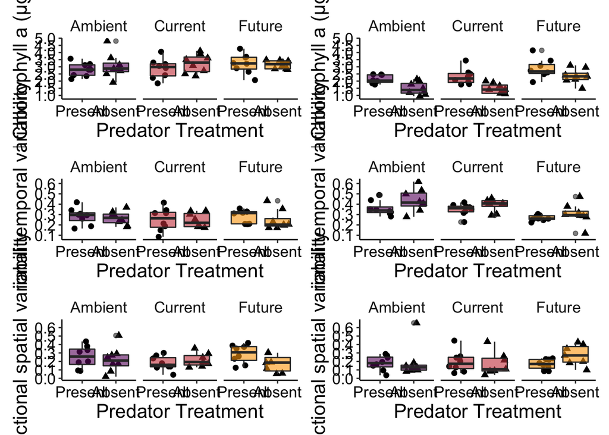

```r
# plot multipanel figure using patchwork
(Func_plot1 + Func_plot2) / (Func_plot3 + Func_plot4) / (Func_plot5 + Func_plot6)
```

```r
# remove results dataframes to save space
rm(Peak.CV,Peak.end,Peak.space,Peak.ts,Recov.ts,Recovery.end,Recovery.CV,Recovery.space,Space.Var,Space,Bentho.Mean)
```

## Compositional stability

Now let’s look for treatment effects on algal composition and compositional temporal and spatial variability.

**Mean values**

We’ll use the mean of our tiles within each measocosm to look for treatment effects on algal composition and variability. We’ll have to re-create the Bentho.Mean dataframe, this time taking means of the three algal groups (green algae, cyanobacteria, and diatoms; see Methods):

```r
# Here we'll get the mean values to use for our plots. We can use $Mesocosm.No as an index to calculate across the three spatial replicates each day

Bentho.Mean<-distinct(Bentho,Date,Mesocosm.No,.keep_all = TRUE) # for each date get unique date x mesocosm.no
Bentho.Mean<-Bentho.Mean[,c(1,6:9,11)] # remove data
Bentho.Mean<-as.data.frame(Bentho.Mean) # convert to dataframe to allow cbind
Bentho.Mean<-cbind(Bentho.Mean,Green.Mean=NA,Cyano.Mean=NA,Diatom.Mean=NA) # cbind the mean columns on

# get mean of each variable for each date x mesocosm
for (i in 1:nrow(Bentho.Mean)) {
  Bentho.Mean$Green.Mean[i]<-mean(Bentho$Green.Algae[Bentho$Date %in% Bentho.Mean$Date[i] &
                                                       Bentho$Mesocosm.No %in% Bentho.Mean$Mesocosm.No[i]],na.rm = T) # get mean of green algae across tiles
  Bentho.Mean$Cyano.Mean[i]<-mean(Bentho$Cyano[Bentho$Date %in% Bentho.Mean$Date[i] &
                                                 Bentho$Mesocosm.No %in% Bentho.Mean$Mesocosm.No[i]],na.rm = T)  # get mean of cyanobacteria across tiles
  Bentho.Mean$Diatom.Mean[i]<-mean(Bentho$Diatoms[Bentho$Date %in% Bentho.Mean$Date[i] &
                                                    Bentho$Mesocosm.No %in% Bentho.Mean$Mesocosm.No[i]],na.rm = T)  # get mean of diatoms across tiles
}

Bentho.Mean$Mesocosm.No<-as.character(Bentho.Mean$Mesocosm.No)

# label appropriate periods
Bentho.Mean$Period2<-NA
Bentho.Mean$Period2[Bentho.Mean$Period %in% "Initial"]<-"Colonisation"
Bentho.Mean$Period2[Bentho.Mean$Period %in% "Recovery"]<-"Recovery"
Bentho.Mean$Period2[Bentho.Mean$Period %in% c("Ambient","Ambient.1","Ambient.2")]<-"Control"
Bentho.Mean$Period2[Bentho.Mean$Date %in% parse_datetime(c("2019-07-30","2019-07-31"),locale = locale(tz = "Japan")) &
                      Bentho.Mean$Heat.Treatment %!in% "Ambient"]<-"Onset"
Bentho.Mean$Period2[Bentho.Mean$Date %in% parse_datetime(c("2019-08-01","2019-08-02","2019-08-03","2019-08-04","2019-08-05"),
                                                         locale = locale(tz = "Japan")) &
                      Bentho.Mean$Heat.Treatment %!in% "Ambient"]<-"Peak"
Bentho.Mean$Period2[Bentho.Mean$Date %in% parse_datetime(c("2019-08-06","2019-08-07","2019-08-08"),
                                                         locale = locale(tz = "Japan")) &
                      Bentho.Mean$Heat.Treatment %!in% "Ambient"]<-"Decline"

Bentho.Mean$Period2<-parse_factor(Bentho.Mean$Period2,
                                   levels = c("Control","Colonisation","Onset","Peak","Decline","Recovery"),
                                   ordered = T,
                                   include_na = F)
```

**Bray-Curtis dissimilarity**

First, we’ll produce the Hellinger transformed community matrix which is basically the square root transformation of relative abundance, but is even less sensitive to abundance (particularly in the case of large numbers of taxa). Hellinger transformations do not give high weights to rare species. Legendre & Gallagher (2001, *Oecologia*) suggest using Hellinger transformation before ordination *unless* one wants to give high weight to rare species.

```r
Bentho.Mean[,7:9] <- decostand(Bentho.Mean[,7:9], "hellinger") # Hellinger-transform the species dataset
```

Now we have Hellinger-transformed algae data from which we can calculate Bray Curtis (dis)similarity. We’ll get the compositional struture of our algal communities on the 2 key dates (end of heatwave peak, end of experiment):

```r
Peak_structure<-Bentho.Mean[Bentho.Mean$Date %in% parse_datetime("2019-08-05",locale = locale(tz = "Japan")),7:9] # End of peak heatwave
rownames(Peak_structure)<-as.character(C.Comp$Treat.Name)

Recov_structure<-Bentho.Mean[Bentho.Mean$Date %in% parse_datetime("2019-08-28",locale = locale(tz = "Japan")),7:9] # End of experiment
rownames(Recov_structure)<-as.character(C.Comp$Treat.Name)
```

That’s our separate times, so now we’ll use Nonmetric Multidimensional Scaling as our ordination technique before testing for treatment effects:

```
## *** Solution reached
```

```
## *** Solution reached
```

**Treatment effects on algal composition**

Now we’ll do the stats to test for treatment effects on algal community structure. Note the post-hoc tests require the pairwiseAdonis package, available from github:

```r
# use pairwiseAdonis function as equivalent posthoc pairwise test
#library(devtools) (not run)
#install_github("pmartinezarbizu/pairwiseAdonis/pairwiseAdonis") (not run)
require(pairwiseAdonis)
```

```r
##-- end of heatwave peak --##

# use Vegan's adonis2() to test significance of predators, heatwaves, and their interaction
adonis2(formula = Peak_structure ~ data.scores_Peak$Pred.Treatment,
        permutations = 10000)
```

```
## Permutation test for adonis under reduced model
## Terms added sequentially (first to last)
## Permutation: free
## Number of permutations: 10000
##
## adonis2(formula = Peak_structure ~ data.scores_Peak$Pred.Treatment, permutations = 10000)
##                                 Df SumOfSqs      R2      F Pr(>F)
## data.scores_Peak$Pred.Treatment  1 0.006497 0.17085 9.4788  4e-04 ***
## Residual                        46 0.031529 0.82915
## Total                           47 0.038025 1.00000
## ---
## Signif. codes:  0 '***' 0.001 '**' 0.01 '*' 0.05 '.' 0.1 ' ' 1
```

```r
adonis2(formula = Peak_structure ~ data.scores_Peak$Heat.Treatment,
        permutations = 10000)
```

```
## Permutation test for adonis under reduced model
## Terms added sequentially (first to last)
## Permutation: free
## Number of permutations: 10000
##
## adonis2(formula = Peak_structure ~ data.scores_Peak$Heat.Treatment, permutations = 10000)
##                                 Df SumOfSqs      R2      F Pr(>F)
## data.scores_Peak$Heat.Treatment  2 0.000259 0.00681 0.1544 0.9212
## Residual                        45 0.037766 0.99319
## Total                           47 0.038025 1.00000
```

```r
adonis2(formula = Peak_structure ~ data.scores_Peak$Pred.Treatment * data.scores_Peak$Heat.Treatment,
        permutations = 10000)
```

```
## Permutation test for adonis under reduced model
## Terms added sequentially (first to last)
## Permutation: free
## Number of permutations: 10000
##
## adonis2(formula = Peak_structure ~ data.scores_Peak$Pred.Treatment * data.scores_Peak$Heat.Treatment, permutations = 10000)
##                                                                 Df SumOfSqs
## data.scores_Peak$Pred.Treatment                                  1 0.006497
## data.scores_Peak$Heat.Treatment                                  2 0.000259
## data.scores_Peak$Pred.Treatment:data.scores_Peak$Heat.Treatment  2 0.003040
## Residual                                                        42 0.028229
## Total                                                           47 0.038025
##                                                                      R2      F
## data.scores_Peak$Pred.Treatment                                 0.17085 9.6660
## data.scores_Peak$Heat.Treatment                                 0.00681 0.1928
## data.scores_Peak$Pred.Treatment:data.scores_Peak$Heat.Treatment 0.07995 2.2615
## Residual                                                        0.74238
## Total                                                           1.00000
##                                                                    Pr(>F)
## data.scores_Peak$Pred.Treatment                                 0.0005999 ***
## data.scores_Peak$Heat.Treatment                                 0.8968103
## data.scores_Peak$Pred.Treatment:data.scores_Peak$Heat.Treatment 0.0810919 .
## Residual
## Total
## ---
## Signif. codes:  0 '***' 0.001 '**' 0.01 '*' 0.05 '.' 0.1 ' ' 1
```

```r
# post-hoc
pairwise.adonis(Peak_structure,
                factors = data.scores_Peak$Heat.Treatment,
                p.adjust.m = 'bonferroni')
```

```
##                pairs Df    SumsOfSqs    F.Model          R2 p.value p.adjusted
## 1  Future vs Current  1 1.852102e-05 0.02771771 0.000923071   0.856          1
## 2  Future vs Ambient  1 1.529299e-04 0.21874139 0.007238600   0.826          1
## 3 Current vs Ambient  1 2.172468e-04 0.18884280 0.006255384   0.786          1
##   sig
## 1
## 2
## 3
```

```r
##-- end of recovery period --##

# use Vegan's adonis2() to test significance of predators, heatwaves, and their interaction
adonis2(formula = Recov_structure ~ data.scores_Recov$Pred.Treatment,
        permutations = 10000)
```

```
## Permutation test for adonis under reduced model
## Terms added sequentially (first to last)
## Permutation: free
## Number of permutations: 10000
##
## adonis2(formula = Recov_structure ~ data.scores_Recov$Pred.Treatment, permutations = 10000)
##                                  Df SumOfSqs      R2      F Pr(>F)
## data.scores_Recov$Pred.Treatment  1 0.001194 0.01919 0.9002 0.4422
## Residual                         46 0.061022 0.98081
## Total                            47 0.062216 1.00000
```

```r
adonis2(formula = Recov_structure ~ data.scores_Recov$Heat.Treatment,
        permutations = 10000)
```

```
## Permutation test for adonis under reduced model
## Terms added sequentially (first to last)
## Permutation: free
## Number of permutations: 10000
##
## adonis2(formula = Recov_structure ~ data.scores_Recov$Heat.Treatment, permutations = 10000)
##                                  Df SumOfSqs      R2      F Pr(>F)
## data.scores_Recov$Heat.Treatment  2 0.012453 0.20016 5.6308 0.0013 **
## Residual                         45 0.049762 0.79984
## Total                            47 0.062216 1.00000
## ---
## Signif. codes:  0 '***' 0.001 '**' 0.01 '*' 0.05 '.' 0.1 ' ' 1
```

```r
adonis2(formula = Recov_structure ~ data.scores_Recov$Pred.Treatment * data.scores_Peak$Heat.Treatment,
        permutations = 10000)
```

```
## Permutation test for adonis under reduced model
## Terms added sequentially (first to last)
## Permutation: free
## Number of permutations: 10000
##
## adonis2(formula = Recov_structure ~ data.scores_Recov$Pred.Treatment * data.scores_Peak$Heat.Treatment, permutations = 10000)
##                                                                  Df SumOfSqs
## data.scores_Recov$Pred.Treatment                                  1 0.001194
## data.scores_Peak$Heat.Treatment                                   2 0.012453
## data.scores_Recov$Pred.Treatment:data.scores_Peak$Heat.Treatment  2 0.002969
## Residual                                                         42 0.045599
## Total                                                            47 0.062216
##                                                                       R2      F
## data.scores_Recov$Pred.Treatment                                 0.01919 1.0999
## data.scores_Peak$Heat.Treatment                                  0.20016 5.7352
## data.scores_Recov$Pred.Treatment:data.scores_Peak$Heat.Treatment 0.04772 1.3673
## Residual                                                         0.73292
## Total                                                            1.00000
##                                                                  Pr(>F)
## data.scores_Recov$Pred.Treatment                                 0.3709
## data.scores_Peak$Heat.Treatment                                  0.0013 **
## data.scores_Recov$Pred.Treatment:data.scores_Peak$Heat.Treatment 0.2884
## Residual
## Total
## ---
## Signif. codes:  0 '***' 0.001 '**' 0.01 '*' 0.05 '.' 0.1 ' ' 1
```

```r
# post-hoc
pairwise.adonis(Recov_structure,
                factors = data.scores_Recov$Heat.Treatment,
                p.adjust.m = 'bonferroni')
```

```
##                pairs Df    SumsOfSqs   F.Model         R2 p.value p.adjusted
## 1  Future vs Current  1 0.0006016031 0.5077716 0.01664401   0.573      1.000
## 2  Future vs Ambient  1 0.0084861810 7.3442788 0.19666410   0.007      0.021
## 3 Current vs Ambient  1 0.0095922199 9.8158231 0.24653071   0.001      0.003
##   sig
## 1
## 2   .
## 3   *
```

We can then do a Simplirity of Percentages analysis (Simper) to test for which species (in this case, algal groups) are driving significant treatment effects on composition:

```r
##-- signiifcant predator effect during heatwave peak --##

summary(simper(comm = Peak_structure,
               group = data.scores_Peak$Pred.Treatment,
               permutations = 1000))
```

```
##
## Contrast: Absent_Present
##
##              average       sd  ratio     ava     avb cumsum        p
## Cyano.Mean  0.015749 0.013662 1.1528 0.42372 0.46372 0.4936 0.000999 ***
## Diatom.Mean 0.008370 0.007396 1.1318 0.90409 0.88443 0.7560 0.000999 ***
## Green.Mean  0.007786 0.019094 0.4078 0.01315 0.01049 1.0000 1.000000
## ---
## Signif. codes:  0 '***' 0.001 '**' 0.01 '*' 0.05 '.' 0.1 ' ' 1
## Permutation: free
## Number of permutations: 1000
```

```r
##-- signiifcant heatwave effects during recovery period --##

# ambient vs current heatwave
summary(simper(comm = Recov_structure,
               group = data.scores_Recov$Heat.Treatment,
               permutations = 1000))[3]
```

```
## $Current_Ambient
##                 average          sd     ratio        ava        avb    cumsum
## Cyano.Mean  0.021847311 0.015376492 1.4208255 0.38369996 0.43787325 0.4887177
## Green.Mean  0.013057379 0.020579391 0.6344881 0.02495141 0.01696674 0.7808073
## Diatom.Mean 0.009798645 0.007408089 1.3226953 0.92091234 0.89710109 1.0000000
##                      p
## Cyano.Mean  0.09790210
## Green.Mean  0.33766234
## Diatom.Mean 0.04595405
```

```r
# ambient vs future heatwave
summary(simper(comm = Recov_structure,
               group = data.scores_Recov$Heat.Treatment,
               permutations = 1000))[2]
```

```
## $Future_Ambient
##                average          sd     ratio        ava        avb    cumsum
## Cyano.Mean  0.02372541 0.016694267 1.4211709 0.38808122 0.43787325 0.5399787
## Diatom.Mean 0.01055343 0.007427611 1.4208373 0.91887165 0.89710109 0.7801695
## Green.Mean  0.00965884 0.020056456 0.4815826 0.01188544 0.01696674 1.0000000
##                       p
## Cyano.Mean  0.005994006
## Diatom.Mean 0.006993007
## Green.Mean  0.769230769
```

Merge data by significant treatment effects for each period for plotting:

```r
# merge by predator treatment for heatwave peak
gg_pred<-merge(data.scores_Peak,
               aggregate(cbind(mean.x=NMDS1,
                               mean.y=NMDS2)~Pred.Treatment,
                data.scores_Peak,
                mean),
               by="Pred.Treatment")

# merge by heatwave treatment for recovery period
gg_heat<-merge(data.scores_Recov,
               aggregate(cbind(mean.x=NMDS1,
                               mean.y=NMDS2)~Heat.Treatment,
                data.scores_Recov,
                mean),
      by="Heat.Treatment")
```

Now make NMDS figures to represent treatment differences in algal compositional structure:

```r
Comp_plot1<-ggplot(data = gg_pred,
                   mapping = aes(x = NMDS1,
                                 y = NMDS2),
                   group=gg_pred$Pred.Treatment) +
              ylab("NDMS Axis 2") +
              xlab("NMDS Axis 1") +
              theme_classic() +
              theme(text = element_text(size = 16),
                    axis.text = element_text(colour = "black"),
                    legend.title=element_blank(),
                    legend.position = "none") +
              geom_segment(aes(x=mean.x,
                               y=mean.y,
                               xend=NMDS1,
                               yend=NMDS2),
                           col = "black",
                           alpha = 0.2) +
              geom_point(mapping = aes(shape = Pred.Treatment),
                          col = "black",
                         size = 3,alpha = 0.8) +
              geom_point(aes(x=mean.x,
                             y=mean.y,
                             shape = Pred.Treatment),
                         col = "black",
                         size=6) +
              scale_shape_manual(values = c(16,17)) +
              scale_linetype_manual(values = c(1,5)) +
              scale_colour_viridis_d(end = 0.8,begin = 0.3,
                                     option = "inferno") +
              scale_y_continuous(n.breaks = 6) +
              scale_x_continuous(n.breaks = 7)

Comp_plot2<-ggplot(data = gg_heat,
                   mapping = aes(x = NMDS1,
                                 y = NMDS2),
                   group=gg_heat2$Heat.Treatment) +
              ylab("NDMS Axis 2") +
              xlab("NMDS Axis 1") +
              theme_classic() +
              theme(text = element_text(size = 16),
                    axis.text = element_text(colour = "black"),
                    legend.title=element_blank(),
                    legend.position = "none") +
              geom_segment(aes(x=mean.x,
                               y=mean.y,
                               xend=NMDS1,
                               yend=NMDS2,
                             col = Heat.Treatment),
                             alpha = 0.2) +
              geom_point(mapping = aes(col = Heat.Treatment),
                         size = 3,alpha = 0.8) +
              geom_point(aes(x=mean.x,
                             y=mean.y,
                             col = Heat.Treatment),
                         size=6) +
              scale_shape_manual(values = c(1,2)) +
              scale_linetype_manual(values = c(1,5)) +
              scale_colour_viridis_d(end = 0.8,begin = 0.3,
                                     option = "inferno") +
              scale_y_continuous(n.breaks = 6) +
              scale_x_continuous(n.breaks = 7)
```

**Temporal variability**

Now we’re going to calculate the dissimilarity through time to get at temporal variability. We’ll use the Euclidean distance of each mesocosm at time (t) to the centroid of that mesocosm through time.

First, separate out the peak heatwave and total heatwave for calculating variability:

```r
# get time series for calculating CV
Peak.ts<-Bentho.Mean[Bentho.Mean$Date %in% Bentho.Mean$Date[Bentho.Mean$Period2 %in% "Peak"],]
Recov.ts<-Bentho.Mean[Bentho.Mean$Date %in% Bentho.Mean$Date[Bentho.Mean$Period2 %in% "Recovery"],]

# 1) End of peak heatwave
Peak.CV<-Bentho.Mean[Bentho.Mean$Date %in% parse_datetime("2019-08-05",locale = locale(tz = "Japan")),c(2:6,10)]
Peak.CV$Temp.Var<-NA
Recov.CV<-Peak.CV

# convert treatments to factor class for calculating Euclidean distances
Peak.ts$Treatment<-parse_factor(x = as.character(Peak.ts$Treatment),
                                      levels = c("1","2","3","4","5","6"),
                                      ordered = T,
                                      include_na = F)
Recov.ts$Treatment<-parse_factor(x = as.character(Recov.ts$Treatment),
                                 levels = c("1","2","3","4","5","6"),
                                 ordered = T,
                                 include_na = F)
```

Now generate dissimilarity matrices using Bray-Curtis:

```r
##-- Heatwave Peak --##
Peak.mat<-list()
for (i in 1:nrow(Peak.CV)) {

  # separate data for each mesocosm
  Data<-Peak.ts[Peak.ts$Mesocosm.No %in% Peak.CV$Mesocosm.No[i],7:9]

  # calculate dissimilarity between time points
  Peak.mat[[i]]<-vegdist(Data,
                         method="bray",
                         binary=FALSE,
                         diag=TRUE,
                         upper=FALSE,
                         na.rm = TRUE)
}

##-- Recovery Period --##
Recov.mat<-list()
for (i in 1:nrow(Recov.CV)) {

  # separate data for each mesocosm
  Data<-Recov.ts[Recov.ts$Mesocosm.No %in% Recov.CV$Mesocosm.No[i],7:9]

  # calculate dissimilarity between time points
  Recov.mat[[i]]<-vegdist(Data,
                          method="bray",
                          binary=FALSE,
                          diag=TRUE,
                          upper=FALSE,
                          na.rm = TRUE)
}
```

Now we can calculate temporal variability as the mean Euclidean distance to each mesocosm’s date-averaged centroid, where higher values indicate greater dispersion through time (higher variability):

```r
##-- Heatwave Peak --##
for (i in 1:nrow(Peak.CV)) {

  # calculate Euclidean distances to group centroids
  Centroid.Out<-betadisper(d = Peak.mat[[i]],
                 group = Peak.ts$Treatment[Peak.ts$Mesocosm.No %in% Peak.CV$Mesocosm.No[i]], # sets group centroids as mesocosms
                 type = "centroid",
                 sqrt.dist = T)

  # mean of Euclidean distances = temporal variability
  Peak.CV$Temp.Var[i]<-mean(Centroid.Out$distances,na.rm=T)
}

##-- Recovery period --##
for (i in 1:nrow(Recov.CV)) {

  # calculate Euclidean distances to group centroids
  Centroid.Out<-betadisper(d = Recov.mat[[i]],
                 group = Recov.ts$Treatment[Recov.ts$Mesocosm.No %in% Recov.CV$Mesocosm.No[i]],
                 type = "centroid",
                 sqrt.dist = T)

  # mean of Euclidean distances = temporal variability
  Recov.CV$Temp.Var[i]<-mean(Centroid.Out$distances,na.rm=T)

}
```

**Treatment effects on temporal variability**

Now we’ll do the stats to test for treatment effects on the temporal variability of algal community structure:

```r
##-- Heatwave Peak --##
# hist(Peak.CV$Temp.Var) # assess normality (not run)
summary(aov(log10(Temp.Var)~Pred.Treatment*Heat.Treatment,data = Peak.CV)) # run anova
```

```
##                               Df Sum Sq Mean Sq F value Pr(>F)
## Pred.Treatment                 1 0.0130 0.01301   0.961 0.3326
## Heat.Treatment                 2 0.0110 0.00552   0.407 0.6680
## Pred.Treatment:Heat.Treatment  2 0.0902 0.04509   3.329 0.0455 *
## Residuals                     42 0.5689 0.01355
## ---
## Signif. codes:  0 '***' 0.001 '**' 0.01 '*' 0.05 '.' 0.1 ' ' 1
```

```r
# plot(aov(log10(Temp.Var)~Pred.Treatment*Heat.Treatment,data = Peak.CV)) # check assumption of homoscedasticity (not run)
TukeyHSD(aov(log10(Temp.Var)~Pred.Treatment*Heat.Treatment,data = Peak.CV)) # Tukey's HSD post-hoc test checks significance of group differences
```

```
##   Tukey multiple comparisons of means
##     95% family-wise confidence level
##
## Fit: aov(formula = log10(Temp.Var) ~ Pred.Treatment * Heat.Treatment, data = Peak.CV)
##
## $Pred.Treatment
##                      diff         lwr       upr    p adj
## Absent-Present 0.03293195 -0.03486958 0.1007335 0.332598
##
## $Heat.Treatment
##                         diff         lwr        upr     p adj
## Current-Ambient -0.033925770 -0.13389403 0.06604249 0.6900879
## Future-Ambient  -0.003865723 -0.10383398 0.09610254 0.9951464
## Future-Current   0.030060046 -0.06990822 0.13002831 0.7468738
##
## $`Pred.Treatment:Heat.Treatment`
##                                         diff         lwr        upr     p adj
## Absent:Ambient-Present:Ambient   0.153289954 -0.02042687 0.32700678 0.1113474
## Present:Current-Present:Ambient  0.046241131 -0.12747570 0.21995796 0.9669043
## Absent:Current-Present:Ambient   0.039197284 -0.13451954 0.21291411 0.9839234
## Present:Future-Present:Ambient   0.096504387 -0.07721244 0.27022121 0.5659150
## Absent:Future-Present:Ambient    0.049054120 -0.12466271 0.22277095 0.9575275
## Present:Current-Absent:Ambient  -0.107048823 -0.28076565 0.06666800 0.4524805
## Absent:Current-Absent:Ambient   -0.114092670 -0.28780950 0.05962416 0.3814131
## Present:Future-Absent:Ambient   -0.056785566 -0.23050239 0.11693126 0.9230524
## Absent:Future-Absent:Ambient    -0.104235834 -0.27795266 0.06948099 0.4821414
## Absent:Current-Present:Current  -0.007043847 -0.18076067 0.16667298 0.9999961
## Present:Future-Present:Current   0.050263256 -0.12345357 0.22398008 0.9529973
## Absent:Future-Present:Current    0.002812989 -0.17090384 0.17652982 1.0000000
## Present:Future-Absent:Current    0.057307104 -0.11640972 0.23102393 0.9202440
## Absent:Future-Absent:Current     0.009856836 -0.16385999 0.18357366 0.9999791
## Absent:Future-Present:Future    -0.047450268 -0.22116709 0.12626656 0.9630688
```

```r
##-- Recovery Period --##
# hist(Recovery.CV$Temp.Var) # assess normality (not run)
summary(aov(log10(Temp.Var)~Pred.Treatment*Heat.Treatment,data = Recov.CV)) # run anova
```

```
##                               Df  Sum Sq  Mean Sq F value Pr(>F)
## Pred.Treatment                 1 0.00212 0.002125   0.380 0.5411
## Heat.Treatment                 2 0.03057 0.015283   2.731 0.0767 .
## Pred.Treatment:Heat.Treatment  2 0.02119 0.010594   1.893 0.1632
## Residuals                     42 0.23502 0.005596
## ---
## Signif. codes:  0 '***' 0.001 '**' 0.01 '*' 0.05 '.' 0.1 ' ' 1
```

```r
# plot(aov(log10(Temp.Var)~Pred.Treatment*Heat.Treatment,data = Recov.CV)) # check assumption of homoscedasticity (not run)
```

Make plots for multipanel figure:

```r
Y_min<-min(c(Peak.CV$Temp.Var,Recov.CV$Temp.Var),na.rm = T)-0.001
Y_max<-max(c(Peak.CV$Temp.Var,Recov.CV$Temp.Var),na.rm = T)+0.001

Comp_plot3<-ggplot(data = Peak.CV,
                   mapping = aes(x = Pred.Treatment,
                                 y = Temp.Var),
                   group=Heat.Treatment,
                   fill = Period2) +
              ylab("Compositional temporal variability") +
              xlab("Predator Treatment") +
              theme_classic() +
              theme(text = element_text(size = 16),
                    axis.text = element_text(colour = "black"),
                    strip.background = element_blank(),
                    legend.position = "bottom") +
              geom_point(mapping = aes(shape = Pred.Treatment),
                         position = position_jitter(width = 0.35),
                         size = 2,
                         show.legend = FALSE) +
              geom_boxplot(mapping = aes(fill = Heat.Treatment),
                           alpha = 0.6) +
              facet_grid(. ~ Heat.Treatment,
                         scales = 'fixed') +
              scale_shape_manual(values = c(16,17),
                                 guide=FALSE) +
              scale_fill_viridis_d(end = 0.8,begin = 0.3,
                                     option = "inferno",guide=F) +
              scale_y_continuous(limits = c(Y_min,Y_max),
                                 breaks = pretty_breaks(n = 7))


Comp_plot4<-ggplot(data = Recov.CV,
                   mapping = aes(x = Pred.Treatment,
                                 y = Temp.Var),
                   group=Heat.Treatment,
                   fill = Period2) +
              ylab("Compositional temporal variability") +
              xlab("Predator Treatment") +
              theme_classic() +
              theme(text = element_text(size = 16),
                    axis.text = element_text(colour = "black"),
                    strip.background = element_blank(),
                    legend.position = "bottom") +
              geom_point(mapping = aes(shape = Pred.Treatment),
                         position = position_jitter(width = 0.35),
                         size = 2,
                         show.legend = FALSE) +
              geom_boxplot(mapping = aes(fill = Heat.Treatment),
                           alpha = 0.6) +
              facet_grid(. ~ Heat.Treatment,
                         scales = 'fixed') +
              scale_shape_manual(values = c(16,17),
                                 guide=FALSE) +
              scale_fill_viridis_d(end = 0.8,begin = 0.3,
                                     option = "inferno",guide=F) +
              scale_y_continuous(limits = c(Y_min,Y_max),
                                 breaks = pretty_breaks(n = 7))
```

**Spatial variability**

Next, we’ll calculate compositional spatial variability as the mean euclidean distance from each mesocosm to their treatment-level centroid on each day. In this way, we’re testing for treatment-level differences in the heterogeneity between mesocosms.

First, let’s generate our output matrices:

```r
# output matrices
Peak.space<-distinct(.data = Peak.ts,Date,Treatment,.keep_all = TRUE)
Peak.space<-Peak.space[,c(1,3:5,10)]
Peak.space$Space.Var<-NA

Recov.space<-distinct(.data = Recov.ts,Date,Treatment,.keep_all = TRUE)
Recov.space<-Recov.space[,c(1,3:5,10)]
Recov.space$Space.Var<-NA
```

Now generate dissimilarity matrices using Bray-Curtis:

```r
##-- Heatwave peak --##
Peak.mat_space<-list()
for (i in 1:nrow(Peak.space)) {

  # separate data for each treatment on each date
  Data<-Peak.ts[Peak.ts$Treatment %in% Peak.space$Treatment[i] & Peak.ts$Date %in% Peak.space$Date[i],7:9]

  # calculate dissimilarity between mesocosms within a treatment on a particular date
  Peak.mat_space[[i]]<-vegdist(Data,
                               method="bray",
                               binary=FALSE,
                               diag=TRUE,
                               upper=FALSE,
                               na.rm = TRUE)
}

##-- Recovery period --##
Recov.mat_space<-list()
for (i in 1:nrow(Recov.space)) {

  # separate data for each treatment on each date
  Data<-Recov.ts[Recov.ts$Treatment %in% Recov.space$Treatment[i] & Recov.ts$Date %in% Recov.space$Date[i],7:9]

  # calculate dissimilarity between mesocosms within a treatment on a particular date
  Recov.mat_space[[i]]<-vegdist(Data,
                               method="bray",
                               binary=FALSE,
                               diag=TRUE,
                               upper=FALSE,
                               na.rm = TRUE)
}
```

Now we can calculate spatial variability as the mean Euclidean distance to each treatment’s centroid on each date, where higher values indicate higher variability across mesocosms:

```r
##-- Heatwave Peak --##
for (i in 1:nrow(Peak.space)) {

  # calculate Euclidean distances to group centroids
  Centroid.Out<-betadisper(d = Peak.mat_space[[i]],
                 group = Peak.ts$Treatment[Peak.ts$Treatment %in% Peak.space$Treatment[i] & Peak.ts$Date %in% Peak.space$Date[i]], # sets group centroids as treatments per date
                 type = "centroid",
                 sqrt.dist = T)

  # mean of Euclidean distances = spatial variability
  Peak.space$Space.Var[i]<-mean(Centroid.Out$distances,na.rm=T)
}

##-- Recovery period --##
for (i in 1:nrow(Recov.space)) {

  # calculate Euclidean distances to group centroids
  Centroid.Out<-betadisper(d = Recov.mat_space[[i]],
                 group = Recov.ts$Treatment[Recov.ts$Treatment %in% Recov.space$Treatment[i] & Recov.ts$Date %in% Recov.space$Date[i]],
                 type = "centroid",
                 sqrt.dist = T)

  # mean of Euclidean distances = spatial variability
  Recov.space$Space.Var[i]<-mean(Centroid.Out$distances,na.rm=T)
}
```

**Treatment effects on spatial variability**

Now we’ll do the stats to test for treatment effects on the spatial variability of algal community structure. Note that these comparisons are using the different days as replicates per treatment, so the recovery period has N=20 and the heatwave peak has N=5.

```r
##-- Heatwave Peak --##
# hist(Peak.space$Space.Var) # assess normality (not run)
summary(aov(Space.Var~Pred.Treatment*Heat.Treatment,data = Peak.space)) # run anova
```

```
##                               Df   Sum Sq  Mean Sq F value  Pr(>F)
## Pred.Treatment                 1 0.000000 0.000000   0.000 0.99077
## Heat.Treatment                 2 0.001056 0.000528   1.079 0.35596
## Pred.Treatment:Heat.Treatment  2 0.006513 0.003256   6.652 0.00503 **
## Residuals                     24 0.011749 0.000490
## ---
## Signif. codes:  0 '***' 0.001 '**' 0.01 '*' 0.05 '.' 0.1 ' ' 1
```

```r
# plot(aov(Space.Var~Pred.Treatment*Heat.Treatment,data = Peak.space)) # check assumption of homoscedasticity (not run)
TukeyHSD(aov(Space.Var~Pred.Treatment*Heat.Treatment,data = Peak.space)) # Tukey's HSD post-hoc test checks significance of group differences
```

```
##   Tukey multiple comparisons of means
##     95% family-wise confidence level
##
## Fit: aov(formula = Space.Var ~ Pred.Treatment * Heat.Treatment, data = Peak.space)
##
## $Pred.Treatment
##                        diff         lwr        upr     p adj
## Absent-Present 9.439531e-05 -0.01658027 0.01676906 0.9907745
##
## $Heat.Treatment
##                         diff         lwr        upr     p adj
## Current-Ambient  0.008875943 -0.01583463 0.03358652 0.6473520
## Future-Ambient  -0.005528731 -0.03023931 0.01918184 0.8430079
## Future-Current  -0.014404674 -0.03911525 0.01030590 0.3294348
##
## $`Pred.Treatment:Heat.Treatment`
##                                         diff           lwr         upr
## Absent:Ambient-Present:Ambient   0.040868475 -2.398762e-03 0.084135711
## Present:Current-Present:Ambient  0.043187575 -7.966135e-05 0.086454812
## Absent:Current-Present:Ambient   0.015432785 -2.783445e-02 0.058700022
## Present:Future-Present:Ambient   0.021320756 -2.194648e-02 0.064587992
## Absent:Future-Present:Ambient    0.008490257 -3.477698e-02 0.051757493
## Present:Current-Absent:Ambient   0.002319100 -4.094814e-02 0.045586337
## Absent:Current-Absent:Ambient   -0.025435690 -6.870293e-02 0.017831547
## Present:Future-Absent:Ambient   -0.019547719 -6.281496e-02 0.023719517
## Absent:Future-Absent:Ambient    -0.032378218 -7.564545e-02 0.010889018
## Absent:Current-Present:Current  -0.027754790 -7.102203e-02 0.015512446
## Present:Future-Present:Current  -0.021866820 -6.513406e-02 0.021400417
## Absent:Future-Present:Current   -0.034697319 -7.796456e-02 0.008569918
## Present:Future-Absent:Current    0.005887970 -3.737927e-02 0.049155207
## Absent:Future-Absent:Current    -0.006942529 -5.020977e-02 0.036324708
## Absent:Future-Present:Future    -0.012830499 -5.609774e-02 0.030436737
##                                     p adj
## Absent:Ambient-Present:Ambient  0.0718440
## Present:Current-Present:Ambient 0.0506162
## Absent:Current-Present:Ambient  0.8753935
## Present:Future-Present:Ambient  0.6531933
## Absent:Future-Present:Ambient   0.9895091
## Present:Current-Absent:Ambient  0.9999801
## Absent:Current-Absent:Ambient   0.4738258
## Present:Future-Absent:Ambient   0.7284194
## Absent:Future-Absent:Ambient    0.2272962
## Absent:Current-Present:Current  0.3801178
## Present:Future-Present:Current  0.6293445
## Absent:Future-Present:Current   0.1699215
## Present:Future-Absent:Current   0.9980957
## Absent:Future-Absent:Current    0.9958512
## Absent:Future-Present:Future    0.9383040
```

```r
##-- Recovery period --##
# hist(Recov.space$Space.Var) # assess normality (not run)
summary(aov(Space.Var~Pred.Treatment*Heat.Treatment,data = Recov.space)) # run anova
```

```
##                                Df  Sum Sq   Mean Sq F value Pr(>F)
## Pred.Treatment                  1 0.00000 0.0000002   0.000 0.9831
## Heat.Treatment                  2 0.00143 0.0007167   1.778 0.1737
## Pred.Treatment:Heat.Treatment   2 0.00474 0.0023721   5.883 0.0037 **
## Residuals                     114 0.04597 0.0004032
## ---
## Signif. codes:  0 '***' 0.001 '**' 0.01 '*' 0.05 '.' 0.1 ' ' 1
```

```r
# plot(aov(Space.Var~Pred.Treatment*Heat.Treatment,data = Recov.space)) # check assumption of homoscedasticity (not run)
TukeyHSD(aov(Space.Var~Pred.Treatment*Heat.Treatment,data = Recov.space)) # Tukey's HSD post-hoc test checks significance of group differences
```

```
##   Tukey multiple comparisons of means
##     95% family-wise confidence level
##
## Fit: aov(formula = Space.Var ~ Pred.Treatment * Heat.Treatment, data = Recov.space)
##
## $Pred.Treatment
##                        diff          lwr         upr   p adj
## Absent-Present 7.759932e-05 -0.007185041 0.007340239 0.98315
##
## $Heat.Treatment
##                          diff         lwr         upr     p adj
## Current-Ambient -0.0073937292 -0.01805647 0.003269012 0.2304602
## Future-Ambient  -0.0072682535 -0.01793100 0.003394488 0.2419221
## Future-Current   0.0001254758 -0.01053727 0.010788217 0.9995696
##
## $`Pred.Treatment:Heat.Treatment`
##                                         diff           lwr          upr
## Absent:Ambient-Present:Ambient   0.017671916 -0.0007352577  0.036079091
## Present:Current-Present:Ambient  0.004679586 -0.0137275879  0.023086761
## Absent:Current-Present:Ambient  -0.001795128 -0.0202023026  0.016612046
## Present:Future-Present:Ambient   0.007049907 -0.0113572676  0.025457081
## Absent:Future-Present:Ambient   -0.003914497 -0.0223216713  0.014492677
## Present:Current-Absent:Ambient  -0.012992330 -0.0313995044  0.005414844
## Absent:Current-Absent:Ambient   -0.019467045 -0.0378742191 -0.001059871
## Present:Future-Absent:Ambient   -0.010622010 -0.0290291841  0.007785164
## Absent:Future-Absent:Ambient    -0.021586414 -0.0399935878 -0.003179239
## Absent:Current-Present:Current  -0.006474715 -0.0248818890  0.011932459
## Present:Future-Present:Current   0.002370320 -0.0160368539  0.020777495
## Absent:Future-Present:Current   -0.008594083 -0.0270012577  0.009813091
## Present:Future-Absent:Current    0.008845035 -0.0095621392  0.027252209
## Absent:Future-Absent:Current    -0.002119369 -0.0205265429  0.016287806
## Absent:Future-Present:Future    -0.010964404 -0.0293715780  0.007442770
##                                     p adj
## Absent:Ambient-Present:Ambient  0.0675628
## Present:Current-Present:Ambient 0.9768908
## Absent:Current-Present:Ambient  0.9997506
## Present:Future-Present:Ambient  0.8762520
## Absent:Future-Present:Ambient   0.9896334
## Present:Current-Absent:Ambient  0.3232850
## Absent:Current-Absent:Ambient   0.0316378
## Present:Future-Absent:Ambient   0.5525105
## Absent:Future-Absent:Ambient    0.0117088
## Absent:Current-Present:Current  0.9104936
## Present:Future-Present:Current  0.9990326
## Absent:Future-Present:Current   0.7544206
## Present:Future-Absent:Current   0.7311973
## Absent:Future-Absent:Current    0.9994382
## Absent:Future-Present:Future    0.5172205
```

Make plots for multipanel figure:

```r
Y_min<-min(c(Peak.space$Space.Var,Recov.space$Space.Var),na.rm = T)-0.001
Y_max<-max(c(Peak.space$Space.Var,Recov.space$Space.Var),na.rm = T)+0.001

Comp_plot5<-ggplot(data = Peak.space,
                   mapping = aes(x = Pred.Treatment,
                                 y = Space.Var),
                   group=Heat.Treatment,
                   fill = Period2) +
              ylab("Compositional spatial variability") +
              xlab("Predator Treatment") +
              theme_classic() +
              theme(text = element_text(size = 16),
                    axis.text = element_text(colour = "black"),
                    strip.background = element_blank(),
                    legend.position = "bottom") +
              geom_point(mapping = aes(shape = Pred.Treatment),
                         position = position_jitter(width = 0.35),
                         size = 2,
                         show.legend = FALSE) +
              geom_boxplot(mapping = aes(fill = Heat.Treatment),
                           alpha = 0.6) +
              facet_grid(. ~ Heat.Treatment,
                         scales = 'fixed') +
              scale_shape_manual(values = c(16,17),
                                 guide=FALSE) +
              scale_fill_viridis_d(end = 0.8,begin = 0.3,
                                     option = "inferno",guide=F) +
              scale_y_continuous(limits = c(Y_min,Y_max),
                                 breaks = pretty_breaks(n = 7))


Comp_plot6<-ggplot(data = Recov.space,
                   mapping = aes(x = Pred.Treatment,
                                 y = Space.Var),
                   group=Heat.Treatment,
                   fill = Period2) +
              ylab("Compositional spatial variability") +
              xlab("Predator Treatment") +
              theme_classic() +
              theme(text = element_text(size = 16),
                    axis.text = element_text(colour = "black"),
                    strip.background = element_blank(),
                    legend.position = "bottom") +
              geom_point(mapping = aes(shape = Pred.Treatment),
                         position = position_jitter(width = 0.35),
                         size = 2,
                         show.legend = FALSE) +
              geom_boxplot(mapping = aes(fill = Heat.Treatment),
                           alpha = 0.6) +
              facet_grid(. ~ Heat.Treatment,
                         scales = 'fixed') +
              scale_shape_manual(values = c(16,17),
                                 guide=FALSE) +
              scale_fill_viridis_d(end = 0.8,begin = 0.3,
                                     option = "inferno",guide=F) +
              scale_y_continuous(limits = c(Y_min,Y_max),
                                 breaks = pretty_breaks(n = 7))
```

**Multipanel figure**

Finally let’s put all the panels together to produce our multipanel Figure 2. Left panels are for the peak heatwave and right are the recovery period. Top are for compositional structure, middle are for temporal variability, and bottom are for spatial variability.

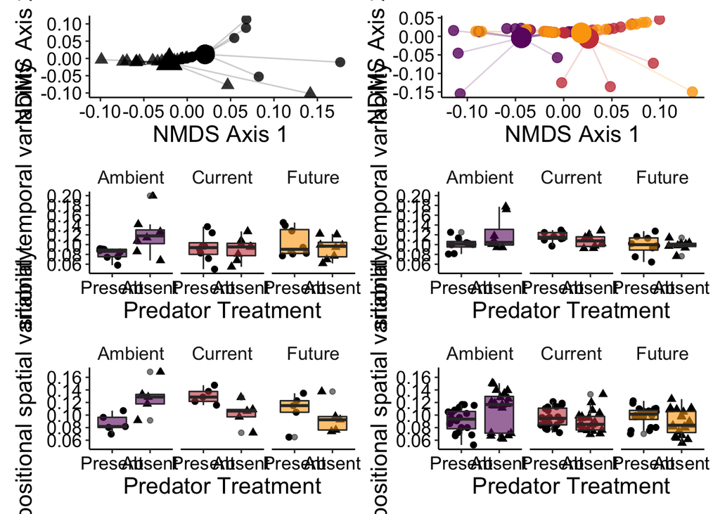

```r
# plot multipanel figure using patchwork
(Comp_plot1 + Comp_plot2) / (Comp_plot3 + Comp_plot4) / (Comp_plot5 + Comp_plot6)
```

```r
# remove results dataframes to save space
rm(Peak.CV,Peak.mat,Peak.ts,Recov.ts,Recov.CV,Recov.space,Bentho.Mean,data.scores_Peak,data.scores_Recov,nmds_Peak,nmds_Recov,Peak_structure,Recov_structure,Centroid.Out,Data,Peak.mat_space,Peak.space,Recov.mat_space,Recov.mat)
```

## Macroinvertebrates

Next we’ll analyse our macroinvertebrate communities to test whether predators or heatwaves affected their composition, richness, or density. We sampled macroinvertebrate communities at the end of the experiment, so this will only be for the end of the recovery period, not for the end of the peak heatwave.

**Bray-Curtis dissimilarity**

First, let’s generate the Bray-Curtis dissimilarity between mesocosms in terms of macroinvertebrate community composition:

```r
# get a suitable community matrix
Invert<-as.data.frame(C.Comp) # convert to dataframe
rownames(Invert)<-as.character(Invert[,29]) # set rownames as unique mesocosm IDs
Invert<-Invert[,c(-1:-5,-25:-29)] # remove all but the species abundance columns
Invert<-decostand(Invert, method = "total") # convert abundance to relative abundance

# run an NMDS on the relative abundance data
Invert_nmds<-metaMDS(comm = Invert,distance = "bray",k = 2,trymax = 100)
```

```
## *** Solution reached
```

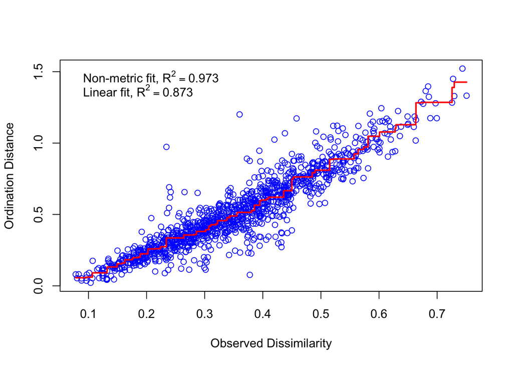

```r
# check stress plot
stressplot(Invert_nmds)
```

```r
## plot NDMS results

#Using the scores function from vegan to extract the site scores and convert to a data.frame
data.scores_Invert <- as.data.frame(scores(Invert_nmds))

# add treatment data to NMDS results
data.scores_Invert$Pred.Treatment <- C.Comp$Pred.Treatment
data.scores_Invert$Heat.Treatment <- C.Comp$Heat.Treatment
data.scores_Invert$Treatment<-C.Comp$Treatment

# convert treatment data to factors
data.scores_Invert$Pred.Treatment<-parse_factor(x = as.character(data.scores_Invert$Pred.Treatment),
                                    ordered = T,
                                    include_na = F,
                                    levels = c("Present","Absent"))
data.scores_Invert$Heat.Treatment<-parse_factor(x = as.character(data.scores_Invert$Heat.Treatment),
                                    ordered = T,
                                    include_na = F,
                                    levels = c("Ambient","Current","Future"))
data.scores_Invert$Treatment<-parse_factor(x = as.character(data.scores_Invert$Treatment),
                                    ordered = F,
                                    include_na = F)
```

**Treatment effects on composition**

Now let’s test the significance of our treatment effects on macroinvertebrate community composition. We’ll use the same adonis2() and pairwise.adnois() framework as we did for algal composition above:

```r
# use adonis2 function from vegan to test significance of predators, heatwaves, and their interaction
adonis2(formula = Invert ~ data.scores_Invert$Pred.Treatment,
        permutations = 10000)
```

```
## Permutation test for adonis under reduced model
## Terms added sequentially (first to last)
## Permutation: free
## Number of permutations: 10000
##
## adonis2(formula = Invert ~ data.scores_Invert$Pred.Treatment, permutations = 10000)
##                                   Df SumOfSqs      R2      F    Pr(>F)
## data.scores_Invert$Pred.Treatment  1   0.4543 0.13617 7.2515 9.999e-05 ***
## Residual                          46   2.8817 0.86383
## Total                             47   3.3359 1.00000
## ---
## Signif. codes:  0 '***' 0.001 '**' 0.01 '*' 0.05 '.' 0.1 ' ' 1
```

```r
adonis2(formula = Invert ~ data.scores_Invert$Heat.Treatment,
        permutations = 10000)
```

```
## Permutation test for adonis under reduced model
## Terms added sequentially (first to last)
## Permutation: free
## Number of permutations: 10000
##
## adonis2(formula = Invert ~ data.scores_Invert$Heat.Treatment, permutations = 10000)
##                                   Df SumOfSqs      R2      F Pr(>F)
## data.scores_Invert$Heat.Treatment  2   0.2955 0.08857 2.1865 0.0296 *
## Residual                          45   3.0405 0.91143
## Total                             47   3.3359 1.00000
## ---
## Signif. codes:  0 '***' 0.001 '**' 0.01 '*' 0.05 '.' 0.1 ' ' 1
```

```r
adonis2(formula = Invert ~ data.scores_Invert$Pred.Treatment * data.scores_Invert$Heat.Treatment,
        permutations = 10000)
```

```
## Permutation test for adonis under reduced model
## Terms added sequentially (first to last)
## Permutation: free
## Number of permutations: 10000
##
## adonis2(formula = Invert ~ data.scores_Invert$Pred.Treatment * data.scores_Invert$Heat.Treatment, permutations = 10000)
##                                                                     Df SumOfSqs
## data.scores_Invert$Pred.Treatment                                    1   0.4543
## data.scores_Invert$Heat.Treatment                                    2   0.2955
## data.scores_Invert$Pred.Treatment:data.scores_Invert$Heat.Treatment  2   0.1466
## Residual                                                            42   2.4396
## Total                                                               47   3.3359
##                                                                          R2
## data.scores_Invert$Pred.Treatment                                   0.13617
## data.scores_Invert$Heat.Treatment                                   0.08857
## data.scores_Invert$Pred.Treatment:data.scores_Invert$Heat.Treatment 0.04394
## Residual                                                            0.73132
## Total                                                               1.00000
##                                                                          F
## data.scores_Invert$Pred.Treatment                                   7.8206
## data.scores_Invert$Heat.Treatment                                   2.5433
## data.scores_Invert$Pred.Treatment:data.scores_Invert$Heat.Treatment 1.2617
## Residual
## Total
##                                                                        Pr(>F)
## data.scores_Invert$Pred.Treatment                                   9.999e-05
## data.scores_Invert$Heat.Treatment                                      0.0142
## data.scores_Invert$Pred.Treatment:data.scores_Invert$Heat.Treatment    0.2483
## Residual
## Total
##
## data.scores_Invert$Pred.Treatment                                   ***
## data.scores_Invert$Heat.Treatment                                   *
## data.scores_Invert$Pred.Treatment:data.scores_Invert$Heat.Treatment
## Residual
## Total
## ---
## Signif. codes:  0 '***' 0.001 '**' 0.01 '*' 0.05 '.' 0.1 ' ' 1
```

```r
# use pairwiseAdonis function as equivalent posthoc pairwise test
library(pairwiseAdonis)
pairwise.adonis(Invert,
                factors = data.scores_Invert$Heat.Treatment,
                p.adjust.m = 'bonferroni') # post-hoc test of heatwave effects
```

```
##                pairs Df  SumsOfSqs   F.Model         R2 p.value p.adjusted sig
## 1  Future vs Current  1 0.11958081 1.7230451 0.05431525   0.133      0.399
## 2  Future vs Ambient  1 0.27050151 3.6007150 0.10716186   0.010      0.030   .
## 3 Current vs Ambient  1 0.05311045 0.9129628 0.02953333   0.485      1.000
```

We can then do a Simplirity of Percentages analysis (Simper) to test for which species are driving significant treatment effects on composition:

```r
##-- signiifcant predator effect --##
summary(simper(comm = Invert,
               group = data.scores_Invert$Pred.Treatment,
               permutations = 1000))
```

```
##
## Contrast: Absent_Present
##
##                             average        sd  ratio       ava       avb cumsum
## Chironomidae spp. A       0.0798951 0.0596422 1.3396 0.2444516 0.1755076 0.2126
## Orthocladiinae spp.       0.0798814 0.0584628 1.3664 0.1373854 0.2819300 0.4251
## Perlodidae spp.           0.0654388 0.0485197 1.3487 0.3248184 0.3605298 0.5992
## Baetis thermicus          0.0440928 0.0560457 0.7867 0.1000910 0.0214115 0.7165
## Sternomoera yezoensis     0.0401837 0.0382184 1.0514 0.1120225 0.0510024 0.8234
## Neophylax japonicus       0.0114312 0.0101963 1.1211 0.0180317 0.0198097 0.8539
## Biwadrilidae spp.         0.0109039 0.0100083 1.0895 0.0196092 0.0193162 0.8829
## Orthocladiinae spp. pupae 0.0105106 0.0110054 0.9550 0.0068662 0.0206675 0.9108
## Brachycentrus americanus  0.0101222 0.0325255 0.3112 0.0041362 0.0179969 0.9378
## Ephemera strigata         0.0077378 0.0074208 1.0427 0.0141261 0.0103730 0.9583
## Rhyacophila nigrocephala  0.0058878 0.0066989 0.8789 0.0072799 0.0101825 0.9740
## Tipula coquilletti        0.0022282 0.0037015 0.6020 0.0030714 0.0018798 0.9799
## Optioservus kubotai       0.0021406 0.0027570 0.7764 0.0030478 0.0021815 0.9856
## Nematoda spp.             0.0021188 0.0030205 0.7015 0.0021544 0.0029583 0.9913
## Psychomyia spp.           0.0016107 0.0025986 0.6198 0.0015939 0.0021536 0.9956
## Cochliopidae spp.         0.0005832 0.0016241 0.3591 0.0002688 0.0009424 0.9971
## Hirudinea spp.            0.0005559 0.0020256 0.2744 0.0003388 0.0008013 0.9986
## Davidius nanus            0.0003534 0.0011991 0.2947 0.0007067 0.0000000 0.9995
## Chironomidae spp. B       0.0001781 0.0008547 0.2083 0.0000000 0.0003561 1.0000
##                                  p
## Chironomidae spp. A       0.178821
## Orthocladiinae spp.       0.000999 ***
## Perlodidae spp.           0.588412
## Baetis thermicus          0.002997 **
## Sternomoera yezoensis     0.000999 ***
## Neophylax japonicus       0.961039
## Biwadrilidae spp.         0.633367
## Orthocladiinae spp. pupae 0.016983 *
## Brachycentrus americanus  0.428571
## Ephemera strigata         0.424575
## Rhyacophila nigrocephala  0.333666
## Tipula coquilletti        0.171828
## Optioservus kubotai       0.353646
## Nematoda spp.             0.701299
## Psychomyia spp.           0.729271
## Cochliopidae spp.         0.480519
## Hirudinea spp.            1.000000
## Davidius nanus            0.515485
## Chironomidae spp. B       1.000000
## ---
## Signif. codes:  0 '***' 0.001 '**' 0.01 '*' 0.05 '.' 0.1 ' ' 1
## Permutation: free
## Number of permutations: 1000
```

```r
##-- signiifcant heatwave effect --##
# ambient vs future heatwave (the significant pairwise difference based on our post-hoc test)
summary(simper(comm = Invert,
               group = data.scores_Invert$Heat.Treatment,
               permutations = 1000))[2]
```

```
## $Future_Ambient
##                                average          sd     ratio          ava
## Chironomidae spp. A       0.0924478174 0.061314244 1.5077706 0.2618324382
## Perlodidae spp.           0.0691036562 0.048963790 1.4113216 0.3036033665
## Orthocladiinae spp.       0.0679979368 0.052171566 1.3033524 0.1703574458
## Baetis thermicus          0.0491661253 0.059712838 0.8233761 0.0539373451
## Sternomoera yezoensis     0.0387741531 0.033824615 1.1463295 0.1006471239
## Biwadrilidae spp.         0.0147416116 0.011771933 1.2522677 0.0345908823
## Brachycentrus americanus  0.0139284815 0.038924388 0.3578343 0.0234517898
## Neophylax japonicus       0.0120732327 0.010959853 1.1015871 0.0152210964
## Orthocladiinae spp. pupae 0.0112223101 0.009534127 1.1770674 0.0000000000
## Ephemera strigata         0.0097601911 0.008512620 1.1465555 0.0075031019
## Rhyacophila nigrocephala  0.0066875483 0.007651541 0.8740132 0.0128212843
## Tipula coquilletti        0.0026722463 0.004359303 0.6129985 0.0044746413
## Optioservus kubotai       0.0026427414 0.003153829 0.8379470 0.0051458216
## Nematoda spp.             0.0024817560 0.003221930 0.7702699 0.0006648936
## Psychomyia spp.           0.0022121004 0.002924841 0.7563147 0.0044242009
## Hirudinea spp.            0.0008550266 0.002470634 0.3460757 0.0000000000
## Cochliopidae spp.         0.0006638529 0.001822686 0.3642167 0.0006868132
## Davidius nanus            0.0005036326 0.001399862 0.3597730 0.0006377551
## Chironomidae spp. B       0.0000000000 0.000000000       NaN 0.0000000000
##                                    avb    cumsum           p
## Chironomidae spp. A       0.1552867372 0.2323192 0.007992008
## Perlodidae spp.           0.3717367579 0.4059751 0.261738262
## Orthocladiinae spp.       0.2260139141 0.5768524 0.469530470
## Baetis thermicus          0.0841665345 0.7004057 0.072927073
## Sternomoera yezoensis     0.0609477319 0.7978442 0.330669331
## Biwadrilidae spp.         0.0105469797 0.8348896 0.000999001
## Brachycentrus americanus  0.0068617394 0.8698915 0.131868132
## Neophylax japonicus       0.0227135540 0.9002313 0.384615385
## Orthocladiinae spp. pupae 0.0224446203 0.9284327 0.161838162
## Ephemera strigata         0.0218545792 0.9529598 0.001998002
## Rhyacophila nigrocephala  0.0076077891 0.9697655 0.213786214
## Tipula coquilletti        0.0015377255 0.9764808 0.181818182
## Optioservus kubotai       0.0006377551 0.9831219 0.056943057
## Nematoda spp.             0.0047844875 0.9893585 0.192807193
## Psychomyia spp.           0.0000000000 0.9949175 0.036963037
## Hirudinea spp.            0.0017100532 0.9970661 0.222777223
## Cochliopidae spp.         0.0007267442 0.9987344 0.430569431
## Davidius nanus            0.0004222973 1.0000000 0.438561439
## Chironomidae spp. B       0.0000000000 1.0000000 1.000000000
```

Plot results for multipanel figure:

```r
# group by heatwave treatments for plotting
gg_heat<-merge(data.scores_Invert,
               aggregate(cbind(mean.x=NMDS1,
                               mean.y=NMDS2)~Heat.Treatment,
                data.scores_Invert,
                mean),
      by="Heat.Treatment")

Invert_plot1<-ggplot(data = gg_heat,
                     mapping = aes(x = NMDS1,
                                   y = NMDS2),
                     group=gg_heat$Heat.Treatment) +
                ylab("NDMS Axis 2") +
                xlab("NMDS Axis 1") +
                theme_classic() +
                theme(text = element_text(size = 16),
                      axis.text = element_text(colour = "black"),
                      legend.title=element_blank(),
                      legend.position = "top") +
                geom_segment(aes(x=mean.x,
                                 y=mean.y,
                                 xend=NMDS1,
                                 yend=NMDS2,
                               col = Heat.Treatment),
                               alpha = 0.2) +
                geom_point(mapping = aes(col = Heat.Treatment),
                           size = 3) +
                geom_point(aes(x=mean.x,
                               y=mean.y,
                               col = Heat.Treatment),
                           size=6) +
                scale_shape_manual(values = c(1,2)) +
                scale_linetype_manual(values = c(1,5)) +
                scale_colour_viridis_d(end = 0.8,begin = 0.3,
                                       option = "inferno") +
                scale_y_continuous(n.breaks = 6) +
                scale_x_continuous(n.breaks = 7)

# group by predator treatments for plotting
gg_pred<-merge(data.scores_Invert,
               aggregate(cbind(mean.x=NMDS1,
                               mean.y=NMDS2)~Pred.Treatment,
                data.scores_Invert,
                mean),
               by="Pred.Treatment")

Invert_plot2<-ggplot(data = gg_pred,
                     mapping = aes(x = NMDS1,
                                   y = NMDS2),
                     group=gg_pred$Pred.Treatment) +
                ylab("NDMS Axis 2") +
                xlab("NMDS Axis 1") +
                theme_classic() +
                theme(text = element_text(size = 16),
                      axis.text = element_text(colour = "black"),
                      legend.title=element_blank(),
                      legend.position = "top") +
                geom_segment(aes(x=mean.x,
                                 y=mean.y,
                                 xend=NMDS1,
                                 yend=NMDS2),
                             col = "black",
                             alpha = 0.2) +
                geom_point(mapping = aes(shape = Pred.Treatment),
                            col = "black",
                           size = 3) +
                geom_point(aes(x=mean.x,
                               y=mean.y,
                               shape = Pred.Treatment),
                           col = "black",
                           size=6) +
                scale_shape_manual(values = c(16,17)) +
                scale_linetype_manual(values = c(1,5)) +
                scale_colour_viridis_d(end = 0.8,begin = 0.3,
                                       option = "inferno") +
                scale_y_continuous(n.breaks = 6) +
                scale_x_continuous(n.breaks = 7)
```

**Treatment effects on richness**

Now we’ll ask how predator and heatwave treatment affected macroinvertebrate richness:

```r
##-- End of recovery period --##
# hist(C.Comp$`Total Richness`) # assess normality (not run)
summary(aov(C.Comp$`Total Richness`~C.Comp$Pred.Treatment*C.Comp$Heat.Treatment)) # run anova
```

```
##                                             Df Sum Sq Mean Sq F value Pr(>F)
## C.Comp$Pred.Treatment                        1   8.33   8.333   5.957  0.019 *
## C.Comp$Heat.Treatment                        2   0.87   0.437   0.313  0.733
## C.Comp$Pred.Treatment:C.Comp$Heat.Treatment  2   1.29   0.646   0.462  0.633
## Residuals                                   42  58.75   1.399
## ---
## Signif. codes:  0 '***' 0.001 '**' 0.01 '*' 0.05 '.' 0.1 ' ' 1
```

```r
# plot(aov(C.Comp$`Total Richness`~C.Comp$Pred.Treatment*C.Comp$Heat.Treatment)) # check assumption of homoscedacity (not run)
TukeyHSD(aov(C.Comp$`Total Richness`~C.Comp$Pred.Treatment*C.Comp$Heat.Treatment)) # Tukey's HSD post-hoc test checks significance of group differences
```

```
##   Tukey multiple comparisons of means
##     95% family-wise confidence level
##
## Fit: aov(formula = C.Comp$`Total Richness` ~ C.Comp$Pred.Treatment * C.Comp$Heat.Treatment)
##
## $`C.Comp$Pred.Treatment`
##                     diff       lwr      upr     p adj
## Absent-Present 0.8333333 0.1443203 1.522346 0.0189527
##
## $`C.Comp$Heat.Treatment`
##                    diff       lwr      upr     p adj
## Current-Ambient -0.0625 -1.078398 0.953398 0.9877628
## Future-Ambient  -0.3125 -1.328398 0.703398 0.7368873
## Future-Current  -0.2500 -1.265898 0.765898 0.8220127
##
## $`C.Comp$Pred.Treatment:C.Comp$Heat.Treatment`
##                                   diff       lwr      upr     p adj
## Absent:Ambient-Present:Ambient   1.000 -0.765346 2.765346 0.5451431
## Present:Current-Present:Ambient  0.250 -1.515346 2.015346 0.9981530
## Absent:Current-Present:Ambient   0.625 -1.140346 2.390346 0.8953826
## Present:Future-Present:Ambient  -0.375 -2.140346 1.390346 0.9877414
## Absent:Future-Present:Ambient    0.750 -1.015346 2.515346 0.8001957
## Present:Current-Absent:Ambient  -0.750 -2.515346 1.015346 0.8001957
## Absent:Current-Absent:Ambient   -0.375 -2.140346 1.390346 0.9877414
## Present:Future-Absent:Ambient   -1.375 -3.140346 0.390346 0.2070062
## Absent:Future-Absent:Ambient    -0.250 -2.015346 1.515346 0.9981530
## Absent:Current-Present:Current   0.375 -1.390346 2.140346 0.9877414
## Present:Future-Present:Current  -0.625 -2.390346 1.140346 0.8953826
## Absent:Future-Present:Current    0.500 -1.265346 2.265346 0.9569902
## Present:Future-Absent:Current   -1.000 -2.765346 0.765346 0.5451431
## Absent:Future-Absent:Current     0.125 -1.640346 1.890346 0.9999373
## Absent:Future-Present:Future     1.125 -0.640346 2.890346 0.4149546
```

Now we’ll plot treatment effects on macroinvertebrate richness (Figure S1).

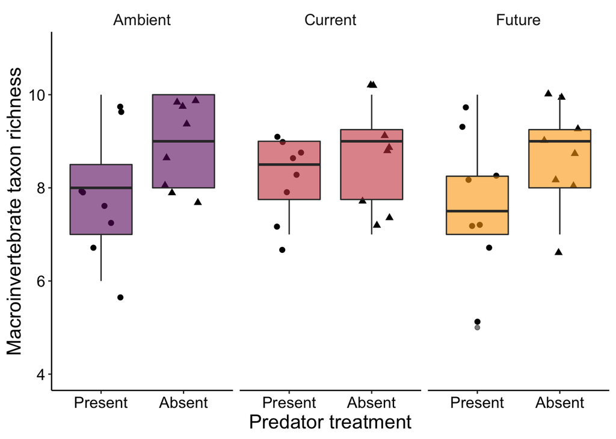

```r
ggplot(data = C.Comp,
       mapping = aes(x = C.Comp$Pred.Treatment,
                     y = C.Comp$`Total Richness`),
       group=C.Comp$Heat.Treatment) +
  ylab("Macroinvertebrate taxon richness") +
  xlab("Predator treatment") +
  theme_classic() +
  theme(text = element_text(size = 16),
        axis.text = element_text(colour = "black"),
        legend.title=element_blank(),
        strip.background = element_blank()) +
  geom_point(mapping = aes(shape = Pred.Treatment),
             position = position_jitter(width = 0.25),
             size = 2,
             show.legend = FALSE) +
  geom_boxplot(mapping = aes(fill = Heat.Treatment),
               alpha = 0.6,
               show.legend = FALSE) +
  facet_grid(. ~ C.Comp$Heat.Treatment,
             scales = 'fixed') +
  ylim(4,max(C.Comp$`Total Richness`)+1) +
  scale_shape_manual(values = c(16,17),
                     guide=FALSE) +
  scale_fill_viridis_d(end = 0.8,begin = 0.3,
                         option = "inferno")
```

**Treatment effects on density**

```r
##-- End of recovery period --##
# hist(C.Comp$`Total Abundance`/35) # assess normality (not run)
summary(aov((C.Comp$`Total Abundance`/35)~C.Comp$Pred.Treatment*C.Comp$Heat.Treatment)) # run anova
```

```
##                                             Df Sum Sq Mean Sq F value   Pr(>F)
## C.Comp$Pred.Treatment                        1 19.544  19.544  31.393 1.48e-06
## C.Comp$Heat.Treatment                        2  1.702   0.851   1.367    0.266
## C.Comp$Pred.Treatment:C.Comp$Heat.Treatment  2  0.154   0.077   0.123    0.884
## Residuals                                   42 26.147   0.623
##
## C.Comp$Pred.Treatment                       ***
## C.Comp$Heat.Treatment
## C.Comp$Pred.Treatment:C.Comp$Heat.Treatment
## Residuals
## ---
## Signif. codes:  0 '***' 0.001 '**' 0.01 '*' 0.05 '.' 0.1 ' ' 1
```

```r
# plot(aov((C.Comp$`Total Abundance`/35)~C.Comp$Pred.Treatment*C.Comp$Heat.Treatment)) # check assumption of homoscedacity (not run)
TukeyHSD(aov((C.Comp$`Total Abundance`/35)~C.Comp$Pred.Treatment*C.Comp$Heat.Treatment)) # Tukey's HSD post-hoc test checks significance of group differences
```

```
##   Tukey multiple comparisons of means
##     95% family-wise confidence level
##
## Fit: aov(formula = (C.Comp$`Total Abundance`/35) ~ C.Comp$Pred.Treatment * C.Comp$Heat.Treatment)
##
## $`C.Comp$Pred.Treatment`
##                   diff       lwr      upr   p adj
## Absent-Present 1.27619 0.8165317 1.735849 1.5e-06
##
## $`C.Comp$Heat.Treatment`
##                       diff        lwr       upr     p adj
## Current-Ambient  0.4571429 -0.2205896 1.1348753 0.2409200
## Future-Ambient   0.1750000 -0.5027324 0.8527324 0.8059983
## Future-Current  -0.2821429 -0.9598753 0.3955896 0.5738742
##
## $`C.Comp$Pred.Treatment:C.Comp$Heat.Treatment`
##                                       diff          lwr        upr     p adj
## Absent:Ambient-Present:Ambient   1.2071429  0.029433799  2.3848519 0.0416901
## Present:Current-Present:Ambient  0.3428571 -0.834851915  1.5205662 0.9517877
## Absent:Current-Present:Ambient   1.7785714  0.600862371  2.9562805 0.0006940
## Present:Future-Present:Ambient   0.1857143 -0.991994772  1.3634233 0.9969196
## Absent:Future-Present:Ambient    1.3714286  0.193719514  2.5491376 0.0141832
## Present:Current-Absent:Ambient  -0.8642857 -2.041994772  0.3134233 0.2635312
## Absent:Current-Absent:Ambient    0.5714286 -0.606280486  1.7491376 0.6977880
## Present:Future-Absent:Ambient   -1.0214286 -2.199137629  0.1562805 0.1225420
## Absent:Future-Absent:Ambient     0.1642857 -1.013423343  1.3419948 0.9982816
## Absent:Current-Present:Current   1.4357143  0.258005228  2.6134233 0.0090638
## Present:Future-Present:Current  -0.1571429 -1.334851915  1.0205662 0.9986116
## Absent:Future-Present:Current    1.0285714 -0.149137629  2.2062805 0.1179442
## Present:Future-Absent:Current   -1.5928571 -2.770566201 -0.4151481 0.0028859
## Absent:Future-Absent:Current    -0.4071429 -1.584851915  0.7705662 0.9044147
## Absent:Future-Present:Future     1.1857143  0.008005228  2.3634233 0.0476063
```

Plot results for multipanel figure:

```r
Invert_plot3<-ggplot(data = C.Comp,
                     mapping = aes(x = C.Comp$Pred.Treatment,
                                   y = C.Comp$`Total Abundance`/35),
                     group=C.Comp$Heat.Treatment) +
                ylab("Macroinvertebrate Density 100 (cm^3)") +
                xlab("Predator treatment") +
                theme_classic() +
                theme(text = element_text(size = 16),
                      axis.text = element_text(colour = "black"),
                      legend.title=element_blank(),
                      strip.background = element_blank()) +
                geom_point(mapping = aes(shape = Pred.Treatment),
                           position = position_jitter(width = 0.25),
                           size = 2,
                           show.legend = FALSE) +
                geom_boxplot(mapping = aes(fill = Heat.Treatment),
                             alpha = 0.6,
                             show.legend = FALSE) +
                facet_grid(. ~ C.Comp$Heat.Treatment,
                           scales = 'fixed') +
                ylim(0,6) +
                scale_shape_manual(values = c(16,17),
                                   guide=FALSE) +
                scale_fill_viridis_d(end = 0.8,begin = 0.3,
                                       option = "inferno")
```

## Leaf litter processing

Finally, let’s test for treatment effects on leaf litter processing. We’ll test both microbial degradation and leaf shredding by macroinvertebrates.

**Treatment effects on microbial degradation**

First convert treatments to factors:

```r
# convert to factor for plotting and analysis
Leaf$Pred.Treatment<-parse_factor(x = as.character(Leaf$Pred.Treatment),
                                    ordered = T,
                                    include_na = F,
                                    levels = c("Present","Absent"))

Leaf$Heat.Treatment<-parse_factor(x = as.character(Leaf$Heat.Treatment),
                                    ordered = T,
                                    include_na = F,
                                    levels = c("Ambient","Current","Future"))
```

Then analyse treatment effects on microbial degradation:

```r
##-- End of recovery period --##

# hist(log10(Leaf$micro.degred.factor)) # assess normality (not run)
summary(aov(log10(Leaf$micro.degred.factor)~Leaf$Pred.Treatment*Leaf$Heat.Treatment))
```

```
##                                         Df  Sum Sq  Mean Sq F value Pr(>F)
## Leaf$Pred.Treatment                      1 0.00063 0.000635   0.104  0.749
## Leaf$Heat.Treatment                      2 0.00164 0.000819   0.134  0.875
## Leaf$Pred.Treatment:Leaf$Heat.Treatment  2 0.00224 0.001120   0.184  0.833
## Residuals                               42 0.25628 0.006102
```

```r
# plot(aov(log10(Leaf$micro.degred.factor)~Leaf$Pred.Treatment*Leaf$Heat.Treatment)) # check assumption of homoscedacity (not run)
```

Plot results:

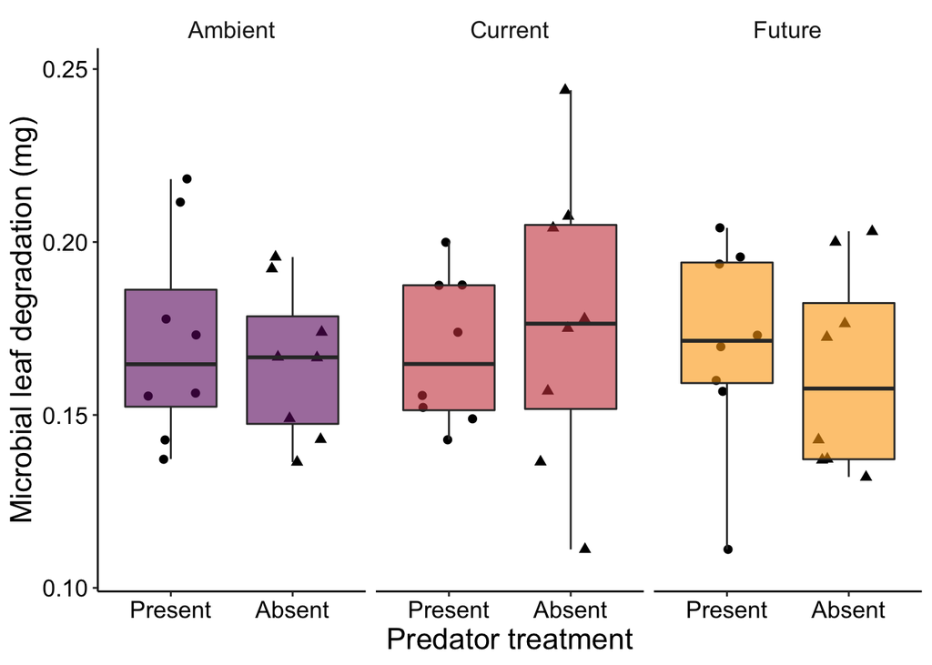

```r
ggplot(data = Leaf,
       mapping = aes(x = Leaf$Pred.Treatment,
                     y = Leaf$micro.degred.factor),
       group=Leaf$Heat.Treatment) +
  ylab("Microbial leaf degradation (mg)") +
  xlab("Predator treatment") +
  theme_classic() +
  theme(text = element_text(size = 16),
        axis.text = element_text(colour = "black"),
        legend.title=element_blank(),
        strip.background = element_blank()) +
  geom_point(mapping = aes(shape = Pred.Treatment),
             position = position_jitter(width = 0.25),
             size = 2,
             show.legend = FALSE) +
  geom_boxplot(mapping = aes(fill = Heat.Treatment),
               alpha = 0.6,
               show.legend = FALSE) +
  facet_grid(. ~ Leaf$Heat.Treatment,
             scales = 'fixed') +
  ylim(min(Leaf$micro.degred.factor)-0.005,max(Leaf$micro.degred.factor)+0.005) +
  scale_shape_manual(values = c(16,17),
                     guide=FALSE) +
  scale_fill_viridis_d(end = 0.8,begin = 0.3,
                         option = "inferno")
```

**Treatment effects on macroinvertebrate shredding**

So finally we’ll test for treatment effects on leaf shredding by macroinvertebrates, using our corrected values (accounting for microbial degradation, where negative values indicate an interaction between macroinvertebrate and microbial breakdown; see Methods):

```r
##-- End of recovery period --##

# hist(Leaf$Corrected.shred)  # assess normality (not run)
summary(aov(Leaf$Corrected.shred~Leaf$Pred.Treatment*Leaf$Heat.Treatment)) # run anova
```

```
##                                         Df Sum Sq Mean Sq F value   Pr(>F)
## Leaf$Pred.Treatment                      1 0.2378 0.23784  13.471 0.000678 ***
## Leaf$Heat.Treatment                      2 0.0053 0.00267   0.151 0.860076
## Leaf$Pred.Treatment:Leaf$Heat.Treatment  2 0.0003 0.00014   0.008 0.992279
## Residuals                               42 0.7415 0.01766
## ---
## Signif. codes:  0 '***' 0.001 '**' 0.01 '*' 0.05 '.' 0.1 ' ' 1
```

```r
# plot(aov(Leaf$Corrected.shred~Leaf$Pred.Treatment*Leaf$Heat.Treatment)) # check assumption of homoscedacity (not run)
TukeyHSD(aov(Leaf$Corrected.shred~Leaf$Pred.Treatment*Leaf$Heat.Treatment)) # Tukey's HSD post-hoc test checks significance of group differences
```

```
##   Tukey multiple comparisons of means
##     95% family-wise confidence level
##
## Fit: aov(formula = Leaf$Corrected.shred ~ Leaf$Pred.Treatment * Leaf$Heat.Treatment)
##
## $`Leaf$Pred.Treatment`
##                     diff        lwr       upr     p adj
## Absent-Present 0.1407839 0.06337486 0.2181929 0.0006779
##
## $`Leaf$Heat.Treatment`
##                         diff         lwr       upr     p adj
## Current-Ambient  0.025170702 -0.08896307 0.1393045 0.8542084
## Future-Ambient   0.017647314 -0.09648646 0.1317811 0.9253061
## Future-Current  -0.007523389 -0.12165716 0.1066104 0.9859653
##
## $`Leaf$Pred.Treatment:Leaf$Heat.Treatment`
##                                         diff         lwr        upr     p adj
## Absent:Ambient-Present:Ambient   0.145119505 -0.05321302 0.34345203 0.2664964
## Present:Current-Present:Ambient  0.030665135 -0.16766739 0.22899766 0.9971940
## Absent:Current-Present:Ambient   0.164795774 -0.03353675 0.36312829 0.1532311
## Present:Future-Present:Ambient   0.018656340 -0.17967618 0.21698886 0.9997461
## Absent:Future-Present:Ambient    0.161757792 -0.03657473 0.36009031 0.1678135
## Present:Current-Absent:Ambient  -0.114454370 -0.31278689 0.08387815 0.5250482
## Absent:Current-Absent:Ambient    0.019676270 -0.17865625 0.21800879 0.9996705
## Present:Future-Absent:Ambient   -0.126463165 -0.32479569 0.07186936 0.4143185
## Absent:Future-Absent:Ambient     0.016638288 -0.18169423 0.21497081 0.9998553
## Absent:Current-Present:Current   0.134130639 -0.06420188 0.33246316 0.3492285
## Present:Future-Present:Current  -0.012008795 -0.21034132 0.18632373 0.9999711
## Absent:Future-Present:Current    0.131092657 -0.06723986 0.32942518 0.3743651
## Present:Future-Absent:Current   -0.146139435 -0.34447196 0.05219309 0.2595122
## Absent:Future-Absent:Current    -0.003037982 -0.20137050 0.19529454 1.0000000
## Absent:Future-Present:Future     0.143101453 -0.05523107 0.34143397 0.2806722
```

Plot for multipanel figure:

```r
Invert_plot4<-ggplot(data = Leaf,
                     mapping = aes(x = Leaf$Pred.Treatment,
                                   y = Leaf$Corrected.shred),
                     group=Leaf$Heat.Treatment) +
                ylab("Leaf litter processing (mg)") +
                xlab("Predator treatment") +
                theme_classic() +
                theme(text = element_text(size = 16),
                      axis.text = element_text(colour = "black"),
                      legend.title=element_blank(),
                      strip.background = element_blank()) +
                geom_point(mapping = aes(shape = Pred.Treatment),
                           position = position_jitter(width = 0.25),
                           size = 2,
                           show.legend = FALSE) +
                geom_boxplot(mapping = aes(fill = Heat.Treatment),
                             alpha = 0.6,
                             show.legend = FALSE) +
                facet_grid(. ~ Leaf$Heat.Treatment,
                           scales = 'fixed') +
                ylim(min(Leaf$Corrected.shred)-0.02,max(Leaf$Corrected.shred)+0.02) +
                scale_shape_manual(values = c(16,17),
                                   guide=FALSE) +
                scale_fill_viridis_d(end = 0.8,begin = 0.3,
                                       option = "inferno")
```

**Multipanel figure**

And last but by no means least, here’s the multipanel Figure 3. On the left we have the significant predator and heatwave effects on macroinvertebrate composition, and on the right we have treatment effects on macroinvertebrate density and leaf litter processing:

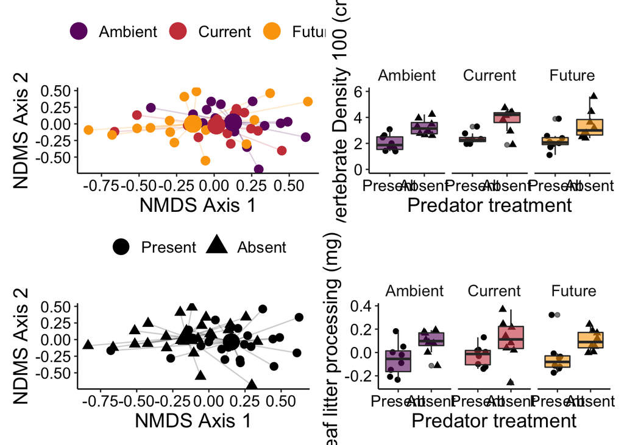

```r
(Invert_plot1 + Invert_plot3) / (Invert_plot2 + Invert_plot4)
```

<sub>Fin</sub>